# Sumário

- 1. Introdução
- 2. Configuração do Projeto e Extração dos Dados
  - 2.1. Importando bibliotecas
  - 2.2. Extração dos Dados (API)
  - 2.3. Carregamento dos Dados
- 3. Busca exploratória dos dados e Análise Qualitativa
  - 3.1. Análise Macroscópica (Descrição dos Dados)
  - 3.2. Análise Microscópica (Exploração e Qualidade dos Dados)
- 4. Tratamento Final e Armazenamento
- 5. Visualização de Dados (Análise Gráfica)
- 6. Conclusão

# 1. Introdução

A transparência e a governança na aplicação de recursos públicos são pilares fundamentais para a gestão pública e o controle social. Nesse contexto, o Governo Federal instituiu o ObrasGov.br, uma plataforma tecnológica destinada a centralizar, monitorar e dar publicidade aos investimentos federais em infraestrutura. A plataforma visa atender às demandas da sociedade e de órgãos de controle, como o Tribunal de Contas da União (TCU), por informações claras, atualizadas e que permitam o acompanhamento efetivo das políticas públicas.

Este projeto, desenvolvido como parte de um processo seletivo, propõe um ciclo completo de análise de dados focado nos projetos de investimento do Distrito Federal registrados nesta plataforma. Embora o cadastro de projetos com recursos próprios por parte do DF seja facultativo, a análise dos dados federais e locais registrados oferece um panorama crucial sobre os investimentos na capital.

Seguindo uma metodologia estruturada, este notebook documenta todas as etapas do processo:

- Extração (ETL): Coleta dos dados brutos diretamente da API pública do ObrasGov.br.
- Análise Exploratória (EDA): Investigação da qualidade, formato e estrutura dos dados, baseada nas métricas de qualidade da IBM.
- Tratamento e Normalização: Limpeza, correção de inconsistências e transformação de dados complexos (JSON) em um esquema relacional.
- Armazenamento: Persistência dos dados tratados em um banco de dados relacional (SQLite) com integridade referencial.
- Análise e Visualização: Geração de análises quantitativas e qualitativas para extrair insights sobre o perfil, tendências e características das obras no DF.

O objetivo final é demonstrar as capacidades técnicas de manipulação e análise de dados, ao mesmo tempo em que se produz uma avaliação concreta sobre a qualidade dos dados de transparência e os padrões de investimento refletidos na base do ObrasGov.br.

# 2. Configuração do Projeto e Extração dos Dados

## 2.1 Importação

```python
import requests
import pandas as pd
import json
import time
import matplotlib.pyplot as plt
import seaborn as sns
import numpy as np
import unicodedata
import sqlite3
from sqlalchemy import create_engine, text
from IPython.display import display,Markdown
from analise_obras_df.analise import verifica_coluna
from analise_obras_df.analise import sugere_conversao
```

## 2.2. Extração dos Dados (API)

O serviço da API é disponibilizado pela plataforma ObrasGov.br como uma solução tecnológica para a melhoria da governança dos investimentos federais em infraestrutura, por meio do acompanhamento e do monitoramento da execução dos investimentos em projetos de infraestrutura do Governo Federal. A plataforma reúne informações acerca:

- Dados dos projetos de investimentos em infraestrutura;
- Dados dos de georreferenciamento projetos de investimentos em infraestrutura;
- Dados da Execução Física;
- Dados de Execução Financeira;

Para esse projeto, serão utilizados especificamente dados do endpoint "/projeto-investimento", com filtragem focada em informações sobre o Distrito Federal (DF).

Para mais informações relevantes sobre a API acesso disponível em [ObrasGov.br](https://api.obrasgov.gestao.gov.br/obrasgov/api/swagger-ui/index.html#/Projeto%20De%20Investimento/buscarPorFiltro)

No bloco abaixo organiza-se a URL base, endpoint e filtros. Tendo o endereço como base, é feita a requisição (GET).

```python
#URL_BASE = "https://api.obrasgov.gestao.gov.br/obrasgov/api/projeto-investimento"
params_request = {
    'uf': "DF",
    'pagina': 0,
    'tamanhoDaPagina': 100,
    'ordenacao': 'ID_UNICO'
}
db_total = []
db_metadados = []
max_retries = 5
count_retries = 0
print(f"Iniciando requisição para API com os parametros: {params_request}")

while True:
    try:
        response = requests.get(URL_BASE, params = params_request)
        print(f"Requisitando dados da url: {response.url}")

        response.raise_for_status()

        pagina = response.json()
        metadados_da_pagina = pagina.copy()
        metadados_da_pagina.pop('content', None)
        db_metadados.append(metadados_da_pagina)



        if pagina['content']:
            db_total.extend(pagina['content'])
            print(f"Conteúdo da pagina {params_request['pagina']} coletado com sucesso. Total de obras acumuladas {len(db_total)}")

        else:
            print(f"Nenhum resultado encontrado na pagina {params_request['pagina']}. Extração completa")
            break

        print(f"Atualizando pagina {params_request['pagina']} -> {params_request['pagina']+1}")
        params_request['pagina'] += 1
        count_retries = 0
        time.sleep(20)

    except requests.exceptions.HTTPError as http_erro:
        status_code = http_erro.response.status_code
        count_retries += 1

        if count_retries > max_retries:
            print("Finalizando processo de extraçao por excesso de erros.")
            break

        if status_code == 429:
            time_sleep = 60 * count_retries
            print(f"Servidor retornando erro {status_code} - Muitas requisições. Aguardando {time_sleep} segundos para nova tentativa")
            time.sleep(time_sleep)
            continue
        elif status_code >= 500:
            time_sleep = 60
            print(f"Servidor retornando erro {status_code} - Erro no servidor. Aguardando {time_sleep} segundos para nova tentativa")
            time.sleep(time_sleep)
            continue
        else:
            print(f"Erro HTTP inesperado: {http_erro}. Finalizando processo de extração.")
            break

    except requests.exceptions.RequestException as erro:
        print(f"Ocorreu um erro no processo de requisição: <{erro} >")
        print(f"Processo de extração interrompido na pagina {params_request['pagina']}")
        break
```

## 2.3 Carregamento dos Dados

```python
raw_path = "../data/1-raw/"
json_file = "obras_df_raw.json"

meta_path = "../data/1-raw/"
meta_file = "obras_df_metadados.json"
```

### 2.3.1 Armazemento Inicial (RAW)

Nesse primeiro momento, os dados recebidos da requisição, serão armazenados em seu estado bruto, sem nenhum tratamento, na pasta 1-raw/

```python
try:
    with open (raw_path+json_file, 'w', encoding = 'utf-8') as f:
        json.dump(db_total, f, ensure_ascii=False, indent=4)
        display(Markdown((f"Dados brutos armazenados com sucesso. Arquivo: {json_file}")))

except Exception as e:
    print(f"Erro ao armazenar dados brutos: <{e}>")


with open (meta_path+meta_file, 'w', encoding = 'utf-8') as f:
    json.dump(db_metadados, f, ensure_ascii=False, indent=4)
    display(Markdown((f"Metadados armazenados com sucesso. Arquivo: {meta_file}")))
```

### 2.3.2 Carga e Estruturação dos Dados em um DataFrame

Com os dados brutos devidamente armazenados, o próximo bloco é responsável por carregá-los em uma estrutura de dados que nos permita manipulá-los e analisá-los de forma eficiente. Para isso, utilizou-se a biblioteca `pandas` para converter a lista de obras em um **DataFrame**.

```python
try:
    with open(raw_path+json_file, 'r', encoding='utf-8') as f:
        raw_data = json.load(f)

    obras_DF = raw_data
    df = pd.DataFrame(obras_DF)

    display(Markdown(("Dados carregados na dataframe com sucesso")))

except FileNotFoundError:
    print("Arquivo não encontrado")

except Exception as e:
    print(f"Erro encontrado: <{e}>")

estilos_alinhamento = [
    # Regra 1: Alinha todos os cabeçalhos (th = table header) à esquerda
    dict(selector="th", props=[("text-align", "left")]),

    # Regra 2: Alinha todas as células de dados (td = table data) à esquerda
    dict(selector="td", props=[("text-align", "center")])
]
```

Dados carregados na dataframe com sucesso

# 3. Busca exploratória dos dados e Análise Qualitativa

Esse tópico refere-se ao entendimento dos dados e contará com a abordagem descrita pela metodologia [**CRISP-DM**](https://www.datascience-pm.com/crisp-dm-2/) em seu tópico [**II. Data Understanding**](https://www.ibm.com/think/insights/data-quality-metrics). Portanto, após a etapa de coleta inicial dos dados, serão implementados os seguintes processos:

Para o processo de verificação da qualdiade dos Dados, a database será submetida a verificações, tomando como base as métricas de qualidade apresentadas por documentações disponibilizadas pela **IBM**:

- **Data accuracy**: Data correctly represents real-world events and values.
- **Data completeness**: Data contains all necessary records with no missing values.
- **Data consistency**: Data is coherent and standardized across the organization, ensuring that data records in different datasets are compatible.
- **Data timeliness**: Data values are up to date, allowing organizations to avoid making decisions based on stale information.
- **Data uniqueness**: Data is free from redundancies or duplicate records, which can distort analysis.
- **Data validity**: Data conforms to business rules, such as falling within permitted ranges for certain data values and meeting specified data format standards.

Os processos mencionados acima serão organizados em duas fases principais de análise: **Análise Macroscópica**, a qual contém o processo de **Descriçao dos Dados** e **Análise Microscópica**, que englobará a **Exploração** e **Verificação da Qualidade** dos dados.

## 3.1 Análise Macroscópica

3.1.1 Dimensões do Dataframe

- **Total de Registros**: 834

- **Total de Colunas**: 31

3.1.2 Dicionário de Dados

|  | tipo | Valores Nulos |
| --- | --- | --- |
| dataFinalEfetiva | object | 827 |
| dataInicialEfetiva | object | 804 |
| observacoesPertinentes | object | 709 |
| populacaoBeneficiada | object | 670 |
| qdtEmpregosGerados | object | 668 |
| descPopulacaoBeneficiada | object | 664 |
| naturezaOutras | object | 629 |
| descPlanoNacionalPoliticaVinculado | object | 558 |
| cep | object | 445 |
| endereco | object | 406 |
| isModeladaPorBim | object | 246 |
| especie | object | 4 |
| dataInicialPrevista | object | 2 |
| dataFinalPrevista | object | 2 |
| metaGlobal | object | 0 |
| natureza | object | 0 |
| dataCadastro | object | 0 |
| funcaoSocial | object | 0 |
| idUnico | object | 0 |
| nome | object | 0 |
| descricao | object | 0 |
| uf | object | 0 |
| situacao | object | 0 |
| dataSituacao | object | 0 |
| tomadores | object | 0 |
| executores | object | 0 |
| repassadores | object | 0 |
| eixos | object | 0 |
| tipos | object | 0 |
| subTipos | object | 0 |
| fontesDeRecurso | object | 0 |

3.1.3 Análise de Completude Geral

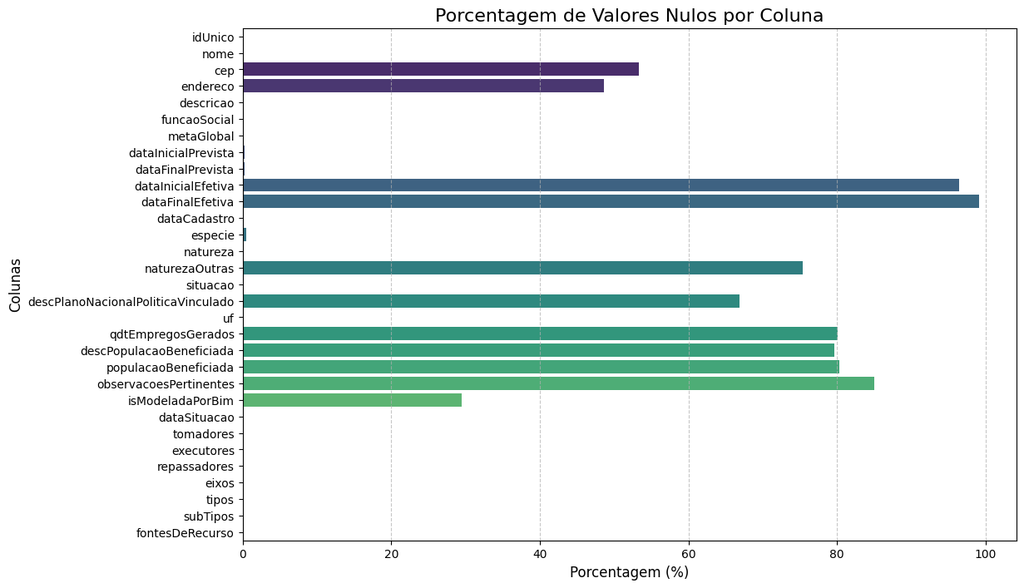

3.1.4 Análise de Unicidade Geral

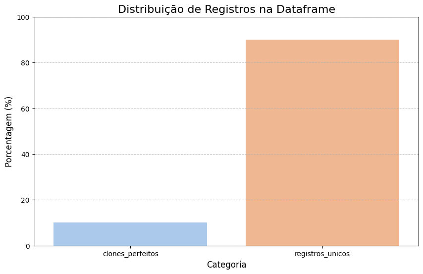

Registros únicos: 750 (89.93%)

Registros duplicados: 84 (10.07%)

```python
nulos_por_coluna = {}
df_temp = df.copy()
colunas_unhashble = []
for coluna in df.columns:
    # Verifica colunas com características unhashble
    if df[coluna].apply(lambda x: isinstance(x, (list, dict))).any():
        # Converte a coluna para string para permitir a verificação de duplicatas
        df_temp[coluna] = df_temp[coluna].astype('string')
        colunas_unhashble.append(coluna)
    # Verifica coluna por coluna a quantidade de valores nulos
    nulos_por_coluna[coluna] = df[coluna].isnull().sum()

# Gera nova dataframe sem as linhas que são clones perfeitos
indices_limpos = df_temp.drop_duplicates().index
df_limpa = df.loc[indices_limpos]

# Apresentação dos resultados

dicionario_df = pd.DataFrame(index=df.columns)
dicionario_df['tipo'] = df.dtypes
dicionario_df['Valores Nulos'] = nulos_por_coluna.values()

nulos_series = pd.Series(nulos_por_coluna)
porcentagem_nulos = (nulos_series / len(df)) * 100

distribuicao_df = {}
distribuicao_df['clones_perfeitos'] = (len(df) - len(df_limpa)) / len(df) * 100
distribuicao_df['registros_unicos'] = (len(df_limpa)/ len(df) * 100)

display(Markdown((f"""
### 3.1.1 Dimensões do Dataframe
- **Total de Registros**: {len(df)}
- **Total de Colunas**: {len(df.columns)}
"""
)))
display(Markdown(f"### 3.1.2 Dicionário de Dados"))
display(dicionario_df.sort_values(by='Valores Nulos', ascending=False))


display(Markdown(f"### 3.1.3 Análise de Completude Geral"))
plt.figure(figsize=(12, 8))
sns.barplot(x=porcentagem_nulos.values, y=nulos_series.index, hue=nulos_series.index, orient='h', palette='viridis', legend=False)
plt.title('Porcentagem de Valores Nulos por Coluna', fontsize=16)
plt.xlabel('Porcentagem (%)', fontsize=12)
plt.ylabel('Colunas', fontsize=12)
plt.grid(axis='x', linestyle='--', alpha=0.7)
plt.show()

display(Markdown(f"### 3.1.4 Análise de Unicidade Geral"))
plt.figure(figsize=(10, 6))
sns.barplot(x=list(distribuicao_df.keys()), y=list(distribuicao_df.values()), hue=list(distribuicao_df.keys()), palette='pastel', legend=False)
plt.title('Distribuição de Registros na Dataframe', fontsize=16)
plt.ylabel('Porcentagem (%)', fontsize=12)
plt.xlabel('Categoria', fontsize=12)
plt.ylim(0, 100)
plt.grid(axis='y', linestyle='--', alpha=0.7)
plt.show()

display(Markdown(f"Registros únicos: {len(df_limpa)} ({distribuicao_df['registros_unicos']:.2f}%) \n\n Registros duplicados: {len(df) - len(df_limpa)} ({distribuicao_df['clones_perfeitos']:.2f}%)"))
```

A partir dos resultados acima, compreende-se que a estrutura da base de dados contém 31 colunas, demonstrando que há uma riqueza de detalhes sobre as obras. Além disso, há um total de 834 registros de obras relacionados a `uf = DF`.

- Portando a dimensão da base de dados é definida por (linhas,colunas) = (834,31)

Ademais, percebe-se que há colunas específicas com alta `taxa de nulidade´ . Isto posto, tem-se como hipótese inicial que os registros que possuem esses campos nulos se encontram em estágios de desenvolvimento diferente daqueles que os tem preenchidos.

Acerca da `unicidade geral` da database, foram removidas as tuplas que fossem completamente clones, concluindo a primeira etapa de tratamento dos dados. O total de linhas duplicadas era de `84`, restando assim `750` registros da dataframe limpa.

O último resultado demonstrou que foram atribuídas (pela ferramenta `info()`) a tipagem `object` para a totalidade das colunas. O comportamento não é completamente fora do esperado e sinaliza a necessidade mais crítica de tratamento e conversão dos dados. Para uma primeira análise, superficial, a função sugere_conversão infere a melhor tipagem a se atribuir para cada coluna, embora não gere resultados para colunas com características unhashble.

```python
import warnings
warnings.filterwarnings(
    'ignore',
    message="Could not infer format, so each element will be parsed individually.*"
)

display(Markdown("#### Sugestões de Tipos de Dados:"))

sugestoes = {coluna: sugere_conversao(df_limpa[coluna]) for coluna in df_limpa.columns}
dataframe_sugestoes = pd.DataFrame.from_dict(sugestoes, orient='index', columns=['Tipo Sugerido'])

display(dataframe_sugestoes)
```

Sugestões de Tipos de Dados:

|  | Tipo Sugerido |
| --- | --- |
| idUnico | string |
| nome | string |
| cep | string |
| endereco | string |
| descricao | string |
| funcaoSocial | string |
| metaGlobal | string |
| dataInicialPrevista | datetime64[ns] |
| dataFinalPrevista | datetime64[ns] |
| dataInicialEfetiva | datetime64[ns] |
| dataFinalEfetiva | datetime64[ns] |
| dataCadastro | datetime64[ns] |
| especie | category |
| natureza | category |
| naturezaOutras | string |
| situacao | category |
| descPlanoNacionalPoliticaVinculado | string |
| uf | category |
| qdtEmpregosGerados | string |
| descPopulacaoBeneficiada | string |
| populacaoBeneficiada | string |
| observacoesPertinentes | category |
| isModeladaPorBim | bool |
| dataSituacao | datetime64[ns] |
| tomadores | Unhashable |
| executores | Unhashable |
| repassadores | Unhashable |
| eixos | Unhashable |
| tipos | Unhashable |
| subTipos | Unhashable |
| fontesDeRecurso | Unhashable |

## 3.2 Análise Microscópica

Durante a análise microscópica, a ideia será propor uma narrativa que agrupo as colunas de acordo com suas aparentes funções dentro do contexto da base de dados. Essa decisão é feita pois há colunas que não existem isoladamente, mas sim em grupos lógicos de negócio. A princípio, a ferramenta que foi usada para sugerir a tipagem, será usada como auxílio para essa organização.

Ademais, duas abordagens diferentes serão usadas para avaliar os grupos lógicos. Para o grupo de `Identificadores` será abordado com mais foco no processo investigativo do contexto da base de dados, enquanto os restos dos grupos lógicos serão abordados com maior foco na qualidade dos dados.

### 3.2.1 Análise de Colunas **Identificadoras**

#### 3.2.1.1 Coluna [idUnico]

```
array(['50379.53-54', '42724.53-27', '19970.53-78', '24797.53-15',
       '24822.53-70', '4541.53-44', '4545.53-03', '4546.53-60',
       '21324.53-75', '21327.53-34'], dtype=object)
```

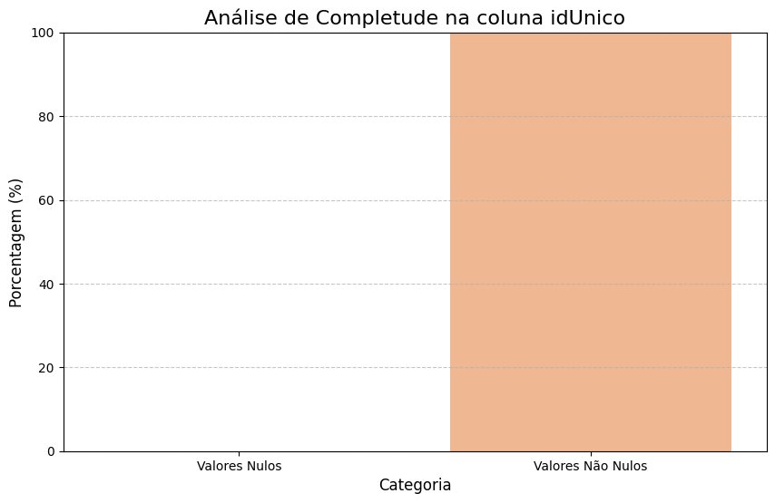

Coluna **idUnico** possui 750 valores preenchidos, correspondendo a 100.00% do total de registros.

Coluna **idUnico** possui 0 valores nulos, correspondendo a 0.00% do total de registros.

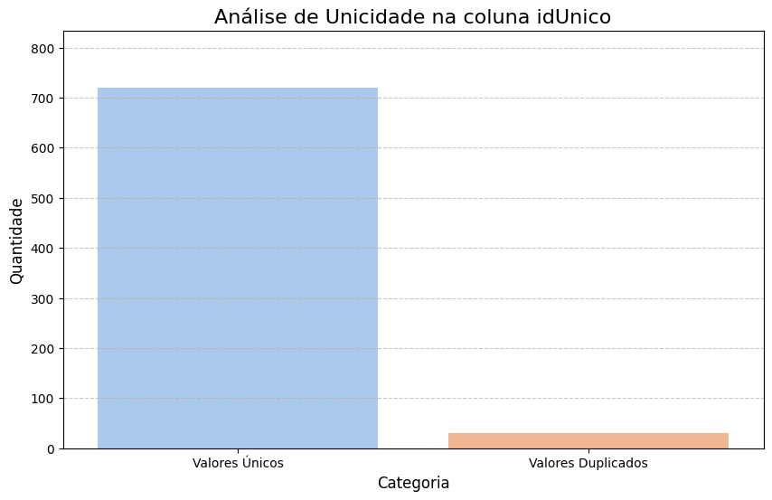

Coluna **idUnico** possui 719 valores únicos, correspondendo a 95.87% do total de registros.

Coluna **idUnico** possui 31 valores duplicados, correspondendo a 4.13% do total de registros.

```python
coluna = 'idUnico'
completude_coluna, unicidade_coluna = verifica_coluna(coluna,df_limpa)
display(df_limpa[coluna].head(10).unique())

plt.figure(figsize=(10, 6))
sns.barplot(x=list(completude_coluna.keys()), y=[(v / len(df_limpa)) * 100 for v in completude_coluna.values()], hue=list(completude_coluna.keys()), palette='pastel', legend=False)
plt.title(f'Análise de Completude na coluna {coluna}', fontsize=16)
plt.ylabel('Porcentagem (%)', fontsize=12)
plt.xlabel('Categoria', fontsize=12)
plt.ylim(0, 100)
plt.grid(axis='y', linestyle='--', alpha=0.7)
plt.show()
display(Markdown(f"Coluna **{coluna}** possui {completude_coluna['Valores Não Nulos']} valores preenchidos, correspondendo a {completude_coluna['Valores Não Nulos'] / len(df_limpa) * 100:.2f}% do total de registros."))
display(Markdown(f"Coluna **{coluna}** possui {completude_coluna['Valores Nulos']} valores nulos, correspondendo a {completude_coluna['Valores Nulos'] / len(df_limpa) * 100:.2f}% do total de registros."))

plt.figure(figsize=(10, 6))
sns.barplot(x=list(unicidade_coluna.keys()), y=list(unicidade_coluna.values()), hue=list(unicidade_coluna.keys()), palette='pastel', legend=False)
plt.title(f'Análise de Unicidade na coluna {coluna}', fontsize=16)
plt.ylabel('Quantidade', fontsize=12)
plt.xlabel('Categoria', fontsize=12)
plt.ylim(0, df[coluna].count())
plt.grid(axis='y', linestyle='--', alpha=0.7)
plt.show()
display(Markdown(f"Coluna **{coluna}** possui {unicidade_coluna['Valores Únicos']} valores únicos, correspondendo a {unicidade_coluna['Valores Únicos'] / len(df_limpa) * 100:.2f}% do total de registros."))
display(Markdown(f"Coluna **{coluna}** possui {unicidade_coluna['Valores Duplicados']} valores duplicados, correspondendo a {unicidade_coluna['Valores Duplicados'] / len(df_limpa) * 100:.2f}% do total de registros."))
```

O primeiro resultado interessante que pode-se analizar, é que a partir do padrão dos 10 primeiros valores preenchidos nessa coluna, é possivel declarar que a melhor tipagem a se atribuir é de fato `string`. O motivo para essa conclusão, é o fato de haver uma mesclagem entre caracteres alfanuméricos.

Após verificado o aspecto tipagem da coluna, a partir dos resultados é viável fazer mais algumas inferências sobre os dados. Os resultados demonstram que a coluna `idUnica` não assume completamente o papel de idenficador dentro da database, como presumia-se a princípio. Enquanto a coluna possui seus valores preenchidos integralmente, com uma taxa de nulidade equivalente a 0%, há um fato curioso que merece atenção:

- **Resultado**: `Quantidade de valores duplicados na coluna [idUnico]: 31`

Todas os registros completamente clonados foram retirados para uma análise mais limpa, porém ainda sim há valores duplicados na coluna `idUnico`. Isto posto, há uma possivel anomalia na coluna que requer uma análise mais profunda. Portanto, primeiro será feita a conversão do tipo `object` para `string`. Após isso, mais alguns processos investigativos serão feitos com o objetivo de determinar o perfil dessas duplicatas e o padrão do campo `idUnico`.

```python
# Conversão object -> string:
df_limpa['idUnico'] = df_limpa['idUnico'].astype('string')
print(f"Sucesso. Nova tipagem atribuída para a tabela [idUnico]: {df['idUnico'].dtype}")

contagem_padrao = df_limpa['idUnico'].str.contains('.53').sum()
porcentagem_padrao = (contagem_padrao / len(df_limpa)) * 100
display(Markdown(f"A coluna **idUnico** possui {contagem_padrao} registros que contém o padrão '.53', correspondendo a {porcentagem_padrao:.2f}% do total de registros."))

padrao_espaco_brancos = df_limpa['idUnico'].str.strip() != df_limpa['idUnico']
if padrao_espaco_brancos.any():
    count_espaco_brancos = padrao_espaco_brancos.sum()
    porcentagem_espaco_brancos = (count_espaco_brancos / len(df_limpa)) * 100
    display(Markdown(f"A coluna **idUnico** possui {count_espaco_brancos} registros com espaços em branco no início ou fim, correspondendo a {porcentagem_espaco_brancos:.2f}% do total de registros."))
else:
    display(Markdown(f"A coluna **idUnico** não possui registros com espaços em branco no início ou fim."))

# Verificação de duplicatas:
display((df_limpa[df_limpa['idUnico'].duplicated(keep=False)]['idUnico'].value_counts()).unique())
print(f"Frequência em que os casos de duplicatas ocorrem:\n {df_limpa[df_limpa['idUnico'].duplicated(keep=False)]['idUnico'].value_counts().value_counts()}")
display(df_limpa['idUnico'].duplicated(keep=False).value_counts())
```

```
Sucesso. Nova tipagem atribuída para a tabela [idUnico]: object
```

A coluna **idUnico** possui 746 registros que contém o padrão '.53', correspondendo a 99.47% do total de registros.

A coluna **idUnico** não possui registros com espaços em branco no início ou fim.

```
<IntegerArray>
[2]
Length: 1, dtype: Int64
```

```
Frequência em que os casos de duplicatas ocorrem:
 count
2    31
Name: count, dtype: Int64
```

```
idUnico
False    688
True      62
Name: count, dtype: int64
```

O ultimo resultado trouxe mais algumas informações importantes acerca do perfil da coluna idUnico. Em síntese, tem-se que:

- **Escala Original**: Foram identificados `31` idUnico distintos que possuem valores duplicados.
- **Escala Total**: Ao total, indentificou-se `62` valores envolvidos nos casos de duplicatas (**Originais**: `31`, **Duplicatas**: `31`)
- **Padrão dos Casos de Repetição**: Dentre os casos de duplicatas, descobriu-se que os valores de `idUnico` se repetem apenas `1` vez. Observa-se a proporção de 1:1.

Diante disso, sabe-se que muito provavelmente esses valores indicam algo sobre os padrões e regras de negócio aplicadas a database. Portanto, para encontrar mais detalhes sobre o contexto, o próximo passo é comparar paralelamente os registros duplicados, a fim de encontrar os campos modificados.

```python
grupo_id_duplicados = (df_limpa[df_limpa['idUnico'].duplicated(keep=False)]).groupby('idUnico')
resumo_diference = []
for id_unico, grupo in grupo_id_duplicados:
    diference = grupo.iloc[0] != grupo.iloc[1]
    resumo_diference.append(diference)

df_resumo_diference = pd.DataFrame(resumo_diference)
display(pd.DataFrame(df_resumo_diference.sum()))
```

|  | 0 |
| --- | --- |
| idUnico | 0 |
| nome | 0 |
| cep | 19 |
| endereco | 18 |
| descricao | 0 |
| funcaoSocial | 0 |
| metaGlobal | 0 |
| dataInicialPrevista | 0 |
| dataFinalPrevista | 0 |
| dataInicialEfetiva | 29 |
| dataFinalEfetiva | 30 |
| dataCadastro | 0 |
| especie | 0 |
| natureza | 0 |
| naturezaOutras | 28 |
| situacao | 0 |
| descPlanoNacionalPoliticaVinculado | 24 |
| uf | 0 |
| qdtEmpregosGerados | 29 |
| descPopulacaoBeneficiada | 29 |
| populacaoBeneficiada | 29 |
| observacoesPertinentes | 31 |
| isModeladaPorBim | 5 |
| dataSituacao | 0 |
| tomadores | 0 |
| executores | 0 |
| repassadores | 0 |
| eixos | 0 |
| tipos | 0 |
| subTipos | 31 |
| fontesDeRecurso | 0 |

Os resultados acima apresentam informações sobre quantas vezes cada coluna foi modificada entre os 31 casos de duplicatas.

No casos de clonagem da coluna `idUnico`, tem-se o registro original e o registro posterior, formando um par. Assim, levando em consideração os resultados coletados até o momento, é factível realizar a seguinte inferência:

- A primeira ocorrência de um idUnico representa o cadastro inicial, contendo as informações básicas da obra. A segunda ocorrência, que é criada utilizando o mesmo idUnico, funciona como uma atualização de status ou um registro de conclusão da obra. Os campos que contém a maior frequência de modificação durante esse processo são:
  - DataInicialEfetiva
  - DataFinalEfetiva
  - descPlanoNacionalPoliticaVinculado
  - qtdEmpregosGerados
  - descPopulacaoBeneficiada
  - observacoesPertinentes
  - subTipos

O fato de ser criado um novo registro para atualização dos dados, ao invés de aplicar as mudanças nas tuplas originárias demonstra o motivo de alta taxa de nulidade em algumas colunas da database, além de afirmar a suspeita inicial de que os dados se encontram em estágios de vida diferentes.

**Análise Qualitativa Coluna [idUnico]**:

- Completude esta excelente, ao apresentar 100% dos campos preeenchidos.
- Unicidade da coluna não pode deixar de ser considerada adequada, contando com 95% de valores únicos, embora ainda existam poucos valores duplicados.
- A validade da coluna demonstra ser adequada, considerando que os registros seguem o formato recorrente (`INT`**.**`INT`**-**`INT`) e demonstram relação no contexto de negócio, ao tomar como base que 99.47% dos registros, possuem o seguinte padrão: `INT`.53-`INT`. Fator que provavelmente refere-se a UF = **DF**. Ademais, verificou-se que os registros dessa coluna não apresentavam elementos vazios que pudessem apresentar efeitos fantasmas em análises posteriores.

#### 3.2.1.2 Coluna [nome]

```
array(['DL - 304/2024 - Contratação de instituição para execução de serviços técnico-especializados para realização de atualizações no Método de Dimensionamento de Pavimentos Rígidos do DNI',
       'Escola Classe Crixá São Sebastião',
       'Reajuste do Contrato 45/2021 - Contrução do Centro de Formação e Aperfeiçoamento de Praças - CEFAP do CBMDF',
       'Implantação de Passarelas nas Estradas Parque do DF',
       'obra de construção da  Cabine de Medição, localizado no Setor Central do Campus Universitário Darcy Ribeiro, da Universidade de Brasília, em Brasília/DF',
       '202111-22-Ronald 1', 'Reforma Viveiro Agroecologia',
       'Reforma Agroecologia'], dtype=object)
```

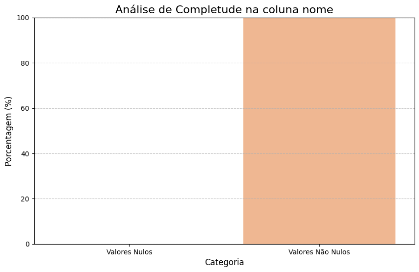

Coluna **nome** possui 750 valores preenchidos, correspondendo a 100.00% do total de registros.

Coluna **nome** possui 0 valores nulos, correspondendo a 0.00% do total de registros.

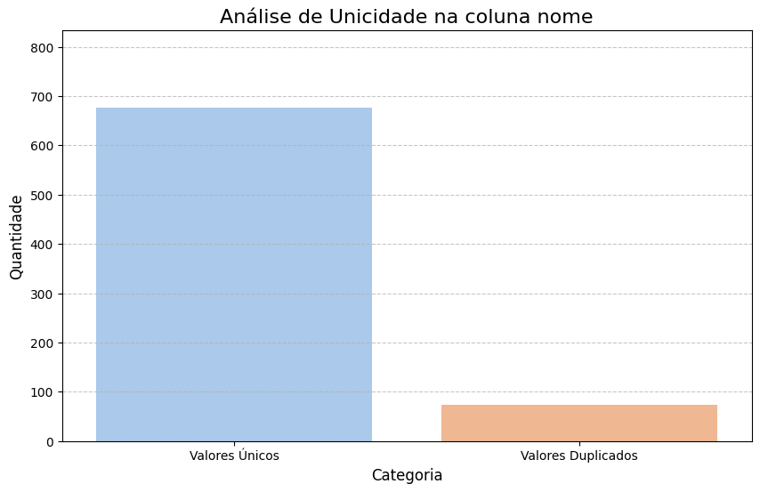

Coluna **nome** possui 676 valores únicos, correspondendo a 90.13% do total de registros.

Coluna **nome** possui 74 valores duplicados, correspondendo a 9.87% do total de registros.

```python
coluna = 'nome'
completude_coluna, unicidade_coluna = verifica_coluna(coluna,df_limpa)
display(df_limpa[coluna].head(10).unique())

plt.figure(figsize=(10, 6))
sns.barplot(x=list(completude_coluna.keys()), y=[(v / len(df_limpa)) * 100 for v in completude_coluna.values()], hue=list(completude_coluna.keys()), palette='pastel', legend=False)
plt.title(f'Análise de Completude na coluna {coluna}', fontsize=16)
plt.ylabel('Porcentagem (%)', fontsize=12)
plt.xlabel('Categoria', fontsize=12)
plt.ylim(0, 100)
plt.grid(axis='y', linestyle='--', alpha=0.7)
plt.show()
display(Markdown(f"Coluna **{coluna}** possui {completude_coluna['Valores Não Nulos']} valores preenchidos, correspondendo a {completude_coluna['Valores Não Nulos'] / len(df_limpa) * 100:.2f}% do total de registros."))
display(Markdown(f"Coluna **{coluna}** possui {completude_coluna['Valores Nulos']} valores nulos, correspondendo a {completude_coluna['Valores Nulos'] / len(df_limpa) * 100:.2f}% do total de registros."))

plt.figure(figsize=(10, 6))
sns.barplot(x=list(unicidade_coluna.keys()), y=list(unicidade_coluna.values()), hue=list(unicidade_coluna.keys()), palette='pastel', legend=False)
plt.title(f'Análise de Unicidade na coluna {coluna}', fontsize=16)
plt.ylabel('Quantidade', fontsize=12)
plt.xlabel('Categoria', fontsize=12)
plt.ylim(0, df[coluna].count())
plt.grid(axis='y', linestyle='--', alpha=0.7)
plt.show()
display(Markdown(f"Coluna **{coluna}** possui {unicidade_coluna['Valores Únicos']} valores únicos, correspondendo a {unicidade_coluna['Valores Únicos'] / len(df_limpa) * 100:.2f}% do total de registros."))
display(Markdown(f"Coluna **{coluna}** possui {unicidade_coluna['Valores Duplicados']} valores duplicados, correspondendo a {unicidade_coluna['Valores Duplicados'] / len(df_limpa) * 100:.2f}% do total de registros."))
```

A coluna nome apresenta alta integridade, com `100%` de preenchimento (nenhum valor nulo). A natureza textual dos dados, com descrições livres e não categóricas, confirma que string é o tipo de dado mais apropriado.

A análise de unicidade revelou que, embora `90.13%` dos valores sejam únicos, existem `74` ocorrências duplicadas. Embora a taxa de duplicagem pareça pequena, dada porcentagem inferior a `10%`, este número é notável, pois é superior (~2x) às `31` duplicatas parciais encontradas na coluna idUnico. Isso indica que ha registros de obras com IDs diferentes que compartilham o mesmo nome. Esse fato é contra-intuitivo, considerando que o campo nome é livre de padrões e formatos, o que teoricamente tornaria mais difícil encontrar valores exatamente iguais.

Observado esse comportamento anômalo, o proximo bloco verifica os nomes que apresentam repetição acima de 2, considerando que aqueles com repetiçao de exatamente 2 se encontram inseridos na proporcionalidade apontada pela análise da coluna de idUnico.

```python
df_limpa['nome'] = df_limpa['nome'].astype('string')

# Apresenta os nomes que mais se repetem
contagem_nomes = df_limpa['nome'].value_counts()
nomes_duplicados = contagem_nomes[contagem_nomes > 2]
display(Markdown("##### Nomes de obras que mais se repetem:"))
display(pd.DataFrame(nomes_duplicados.head(10)).style.set_table_styles(estilos_alinhamento))
```

Nomes de obras que mais se repetem:

| nome | count |
| --- | --- |
| 202111-22-Ronald 1 | 8 |
| PNCV | 6 |
| CONSTRUÇÃO DE UNIDADE BÁSICA DE SAÚDE | 5 |
| Obra de Desenvolvimento de Teste da Websis - Fabrica de Software - MDRR | 5 |
| CONSTRUÇÃO DE UNIDADE DE ATENÇÃO ESPECIALIZADA EM SAÚDE | 5 |
| 00 00377/2020 | 4 |
| Implantação de passarelas em estrutura mista nas rodovias do Sistema Rodoviária do Distrito Federal - SRDF | 4 |
| Novo PAC - Espaços Esportivos Comunitários no Distrito Federal. | 3 |
| SISEG - Sistema integrado de segurança | 3 |

```python
obra_generica = '202111-22-Ronald 1'
display(df_limpa[df_limpa['nome'] == obra_generica])

obra_generica = '00 00377/2020'
display(df_limpa[df_limpa['nome'] == obra_generica])

obra_generica = 'CONSTRUÇÃO DE UNIDADE DE ATENÇÃO ESPECIALIZADA EM SAÚDE'
display(df_limpa[df_limpa['nome'] == obra_generica])
```

|  | idUnico | nome | cep | endereco | descricao | funcaoSocial | metaGlobal | dataInicialPrevista | dataFinalPrevista | dataInicialEfetiva | ... | observacoesPertinentes | isModeladaPorBim | dataSituacao | tomadores | executores | repassadores | eixos | tipos | subTipos | fontesDeRecurso |
| --- | --- | --- | --- | --- | --- | --- | --- | --- | --- | --- | --- | --- | --- | --- | --- | --- | --- | --- | --- | --- | --- |
| 5 | 4541.53-44 | 202111-22-Ronald 1 | 70067-901 | 2021122-Ronald - Endereço Completo | 2021122-Ronald - Descrição do Projeto | 2021122-Ronald - Descrição Funç]ap Social | 20211122-Ronald - Descrição Meta Global | 2021-12-10 | 2021-12-10 | None | ... | None | None | 2021-11-17 | [{'nome': 'FUND.UNIVERSIDADE FEDERAL VALE SAO ... | [{'nome': 'MINISTÉRIO DA INTEGRAÇÃO E DO DESEN... | [{'nome': 'MINISTÉRIO DA INTEGRAÇÃO E DO DESEN... | [{'id': 4, 'descricao': 'Social'}] | [{'id': 45, 'descricao': 'Desenvolvimento', 'i... | [{'id': 38, 'descricao': 'Saneamento', 'idTipo... | [{'origem': 'Federal', 'valorInvestimentoPrevi... |
| 6 | 4545.53-03 | 202111-22-Ronald 1 | 70067-901 | 2021122-Ronald - Endereço Completo | 2021122-Ronald - Descrição do Projeto | 2021122-Ronald - Descrição Funç]ap Social | 20211122-Ronald - Descrição Meta Global | 2021-12-10 | 2021-12-10 | None | ... | None | None | 2021-11-17 | [{'nome': 'FUND.UNIVERSIDADE FEDERAL VALE SAO ... | [{'nome': 'MINISTÉRIO DA INTEGRAÇÃO E DO DESEN... | [{'nome': 'MINISTÉRIO DA INTEGRAÇÃO E DO DESEN... | [{'id': 4, 'descricao': 'Social'}] | [{'id': 45, 'descricao': 'Desenvolvimento', 'i... | [{'id': 38, 'descricao': 'Saneamento', 'idTipo... | [{'origem': 'Federal', 'valorInvestimentoPrevi... |
| 7 | 4546.53-60 | 202111-22-Ronald 1 | 70067-902 | 2021122-Ronald - Endereço Completo | 2021122-Ronald - Descrição do Projeto | 2021122-Ronald - Descrição Funç]ap Social | 20211122-Ronald - Descrição Meta Global | 2021-12-10 | 2021-12-10 | None | ... | None | None | 2021-11-17 | [{'nome': 'FUND.UNIVERSIDADE FEDERAL VALE SAO ... | [{'nome': 'MINISTÉRIO DA INTEGRAÇÃO E DO DESEN... | [{'nome': 'MINISTÉRIO DA INTEGRAÇÃO E DO DESEN... | [{'id': 4, 'descricao': 'Social'}] | [{'id': 45, 'descricao': 'Desenvolvimento', 'i... | [{'id': 38, 'descricao': 'Saneamento', 'idTipo... | [{'origem': 'Federal', 'valorInvestimentoPrevi... |
| 22 | 4539.53-84 | 202111-22-Ronald 1 | 70067-901 | 2021122-Ronald - Endereço Completo | 2021122-Ronald - Descrição do Projeto | 2021122-Ronald - Descrição Funç]ap Social | 20211122-Ronald - Descrição Meta Global | 2021-12-10 | 2021-12-10 | None | ... | None | None | 2021-11-17 | [{'nome': 'FUND.UNIVERSIDADE FEDERAL VALE SAO ... | [{'nome': 'MINISTÉRIO DA INTEGRAÇÃO E DO DESEN... | [{'nome': 'MINISTÉRIO DA INTEGRAÇÃO E DO DESEN... | [{'id': 4, 'descricao': 'Social'}] | [{'id': 45, 'descricao': 'Desenvolvimento', 'i... | [{'id': 38, 'descricao': 'Saneamento', 'idTipo... | [{'origem': 'Federal', 'valorInvestimentoPrevi... |
| 179 | 4543.53-79 | 202111-22-Ronald 1 | 70067-901 | 2021122-Ronald - Endereço Completo | 2021122-Ronald - Descrição do Projeto | 2021122-Ronald - Descrição Funç]ap Social | 20211122-Ronald - Descrição Meta Global | 2021-12-10 | 2021-12-10 | None | ... | None | None | 2021-11-17 | [{'nome': 'FUND.UNIVERSIDADE FEDERAL VALE SAO ... | [{'nome': 'MINISTÉRIO DA INTEGRAÇÃO E DO DESEN... | [{'nome': 'MINISTÉRIO DA INTEGRAÇÃO E DO DESEN... | [{'id': 4, 'descricao': 'Social'}] | [{'id': 45, 'descricao': 'Desenvolvimento', 'i... | [{'id': 38, 'descricao': 'Saneamento', 'idTipo... | [{'origem': 'Federal', 'valorInvestimentoPrevi... |
| 180 | 4540.53-87 | 202111-22-Ronald 1 | 70067-901 | 2021122-Ronald - Endereço Completo | 2021122-Ronald - Descrição do Projeto | 2021122-Ronald - Descrição Funç]ap Social | 20211122-Ronald - Descrição Meta Global | 2021-12-10 | 2021-12-10 | None | ... | None | None | 2021-11-17 | [{'nome': 'FUND.UNIVERSIDADE FEDERAL VALE SAO ... | [{'nome': 'MINISTÉRIO DA INTEGRAÇÃO E DO DESEN... | [{'nome': 'MINISTÉRIO DA INTEGRAÇÃO E DO DESEN... | [{'id': 4, 'descricao': 'Social'}] | [{'id': 45, 'descricao': 'Desenvolvimento', 'i... | [{'id': 38, 'descricao': 'Saneamento', 'idTipo... | [{'origem': 'Federal', 'valorInvestimentoPrevi... |
| 181 | 4542.53-01 | 202111-22-Ronald 1 | 70067-901 | 2021122-Ronald - Endereço Completo | 2021122-Ronald - Descrição do Projeto | 2021122-Ronald - Descrição Funç]ap Social | 20211122-Ronald - Descrição Meta Global | 2021-12-10 | 2021-12-10 | None | ... | None | None | 2021-11-17 | [{'nome': 'FUND.UNIVERSIDADE FEDERAL VALE SAO ... | [{'nome': 'MINISTÉRIO DA INTEGRAÇÃO E DO DESEN... | [{'nome': 'MINISTÉRIO DA INTEGRAÇÃO E DO DESEN... | [{'id': 4, 'descricao': 'Social'}] | [{'id': 45, 'descricao': 'Desenvolvimento', 'i... | [{'id': 38, 'descricao': 'Saneamento', 'idTipo... | [{'origem': 'Federal', 'valorInvestimentoPrevi... |
| 182 | 4544.53-36 | 202111-22-Ronald 1 | 70067-901 | 2021122-Ronald - Endereço Completo | 2021122-Ronald - Descrição do Projeto | 2021122-Ronald - Descrição Funç]ap Social | 20211122-Ronald - Descrição Meta Global | 2021-12-10 | 2021-12-10 | None | ... | None | None | 2021-11-17 | [{'nome': 'FUND.UNIVERSIDADE FEDERAL VALE SAO ... | [{'nome': 'MINISTÉRIO DA INTEGRAÇÃO E DO DESEN... | [{'nome': 'MINISTÉRIO DA INTEGRAÇÃO E DO DESEN... | [{'id': 4, 'descricao': 'Social'}] | [{'id': 45, 'descricao': 'Desenvolvimento', 'i... | [{'id': 38, 'descricao': 'Saneamento', 'idTipo... | [{'origem': 'Federal', 'valorInvestimentoPrevi... |

8 rows × 31 columns

|  | idUnico | nome | cep | endereco | descricao | funcaoSocial | metaGlobal | dataInicialPrevista | dataFinalPrevista | dataInicialEfetiva | ... | observacoesPertinentes | isModeladaPorBim | dataSituacao | tomadores | executores | repassadores | eixos | tipos | subTipos | fontesDeRecurso |
| --- | --- | --- | --- | --- | --- | --- | --- | --- | --- | --- | --- | --- | --- | --- | --- | --- | --- | --- | --- | --- | --- |
| 48 | 1463.53-66 | 00 00377/2020 | 70040-902 | BR-010 | contratação de empresa especializada para pres... | Preservar vidas e promover o desenvolvimento s... | Gerenciamento de 0 km. | None | None | None | ... | None | None | 2021-04-26 | [{'nome': 'DEPARTAMENTO NACIONAL DE INFRAESTRU... | [{'nome': 'DEPARTAMENTO NACIONAL DE INFRAESTRU... | [] | [{'id': 3, 'descricao': 'Econômico'}] | [{'id': 25, 'descricao': 'Rodovia', 'idEixo': 3}] | [{'id': 4, 'descricao': 'Acessos Terrestres', ... | [{'origem': 'Federal', 'valorInvestimentoPrevi... |
| 299 | 1162.53-51 | 00 00377/2020 | 70040-902 | BR-010 | contratação de empresa especializada para pr... | Preservar vidas e promover o desenvolvimento s... | Gerenciamento de 0 km. | 2020-06-25 | 2023-12-21 | None | ... | None | None | 2021-04-26 | [{'nome': 'DEPARTAMENTO NACIONAL DE INFRAESTRU... | [{'nome': 'DEPARTAMENTO NACIONAL DE INFRAESTRU... | [] | [{'id': 3, 'descricao': 'Econômico'}] | [{'id': 25, 'descricao': 'Rodovia', 'idEixo': 3}] | [{'id': 4, 'descricao': 'Acessos Terrestres', ... | [{'origem': 'Federal', 'valorInvestimentoPrevi... |
| 314 | 6008.53-77 | 00 00377/2020 | 70040-902 | BR-010 | contratação de empresa especializada para pr... | Preservar vidas e promover o desenvolvimento s... | Gerenciamento de 0 km. | 2020-06-25 | 2023-12-21 | None | ... | None | None | 2022-05-10 | [{'nome': 'DEPARTAMENTO NACIONAL DE INFRAESTRU... | [{'nome': 'DEPARTAMENTO NACIONAL DE INFRAESTRU... | [] | [{'id': 3, 'descricao': 'Econômico'}] | [{'id': 25, 'descricao': 'Rodovia', 'idEixo': 3}] | [{'id': 4, 'descricao': 'Acessos Terrestres', ... | [{'origem': 'Federal', 'valorInvestimentoPrevi... |
| 820 | 1378.53-71 | 00 00377/2020 | 70040-902 | BR-010 | contratação de empresa especializada para pr... | Preservar vidas e promover o desenvolvimento s... | Supervisão de 0 km. | 2020-06-25 | 2024-09-16 | None | ... | None | None | 2025-08-05 | [{'nome': 'DEPARTAMENTO NACIONAL DE INFRAESTRU... | [{'nome': 'DEPARTAMENTO NACIONAL DE INFRAESTRU... | [] | [{'id': 3, 'descricao': 'Econômico'}] | [{'id': 25, 'descricao': 'Rodovia', 'idEixo': 3}] | [{'id': 4, 'descricao': 'Acessos Terrestres', ... | [{'origem': 'Federal', 'valorInvestimentoPrevi... |

4 rows × 31 columns

|  | idUnico | nome | cep | endereco | descricao | funcaoSocial | metaGlobal | dataInicialPrevista | dataFinalPrevista | dataInicialEfetiva | ... | observacoesPertinentes | isModeladaPorBim | dataSituacao | tomadores | executores | repassadores | eixos | tipos | subTipos | fontesDeRecurso |
| --- | --- | --- | --- | --- | --- | --- | --- | --- | --- | --- | --- | --- | --- | --- | --- | --- | --- | --- | --- | --- | --- |
| 264 | 53528.53-75 | CONSTRUÇÃO DE UNIDADE DE ATENÇÃO ESPECIALIZADA... | 72225-270 | QUADRA QNN 27 | CONSTRUÇÃO DE UNIDADE DE ATENÇÃO ESPECIALIZADA... | CONSTRUÇÃO DE UNIDADE DE ATENÇÃO ESPECIALIZADA... | CONSTRUÇÃO DE UNIDADE DE ATENÇÃO ESPECIALIZADA... | 2024-05-06 | 2024-05-06 | None | ... | None | None | 2025-04-23 | [{'nome': 'FUNDO DE SAUDE DO DISTRITO FEDERAL'... | [{'nome': 'FUNDO DE SAUDE DO DISTRITO FEDERAL'... | [{'nome': 'FUNDO NACIONAL DE SAUDE', 'codigo':... | [{'id': 4, 'descricao': 'Social'}] | [{'id': 39, 'descricao': 'Saúde', 'idEixo': 4}] | [{'id': 78, 'descricao': 'CAPS', 'idTipo': 6}] | [{'origem': 'Federal', 'valorInvestimentoPrevi... |
| 303 | 53528.53-75 | CONSTRUÇÃO DE UNIDADE DE ATENÇÃO ESPECIALIZADA... | 72225-270 | QUADRA QNN 27 | CONSTRUÇÃO DE UNIDADE DE ATENÇÃO ESPECIALIZADA... | CONSTRUÇÃO DE UNIDADE DE ATENÇÃO ESPECIALIZADA... | CONSTRUÇÃO DE UNIDADE DE ATENÇÃO ESPECIALIZADA... | 2024-05-06 | 2024-05-06 | None | ... | None | None | 2025-04-23 | [{'nome': 'FUNDO DE SAUDE DO DISTRITO FEDERAL'... | [{'nome': 'FUNDO DE SAUDE DO DISTRITO FEDERAL'... | [{'nome': 'FUNDO NACIONAL DE SAUDE', 'codigo':... | [{'id': 4, 'descricao': 'Social'}] | [{'id': 39, 'descricao': 'Saúde', 'idEixo': 4}] | [{'id': 78, 'descricao': 'CAPS', 'idTipo': 39}] | [{'origem': 'Federal', 'valorInvestimentoPrevi... |
| 327 | 46882.53-02 | CONSTRUÇÃO DE UNIDADE DE ATENÇÃO ESPECIALIZADA... | 71100-150 | QUADRA EPTG QE 4 | CONSTRUÇÃO DE UNIDADE DE ATENÇÃO ESPECIALIZADA... | CONSTRUÇÃO DE UNIDADE DE ATENÇÃO ESPECIALIZADA... | CONSTRUÇÃO DE UNIDADE DE ATENÇÃO ESPECIALIZADA... | 2024-05-06 | 2024-05-07 | None | ... | None | None | 2024-12-09 | [{'nome': 'FUNDO DE SAUDE DO DISTRITO FEDERAL'... | [{'nome': 'FUNDO DE SAUDE DO DISTRITO FEDERAL'... | [{'nome': 'FUNDO NACIONAL DE SAUDE', 'codigo':... | [{'id': 4, 'descricao': 'Social'}] | [{'id': 39, 'descricao': 'Saúde', 'idEixo': 4}] | [{'id': 78, 'descricao': 'CAPS', 'idTipo': 39}] | [{'origem': 'Federal', 'valorInvestimentoPrevi... |
| 469 | 43192.53-05 | CONSTRUÇÃO DE UNIDADE DE ATENÇÃO ESPECIALIZADA... | 72445-070 | QUADRA 7 | CONSTRUÇÃO DE UNIDADE DE ATENÇÃO ESPECIALIZADA... | CONSTRUÇÃO DE UNIDADE DE ATENÇÃO ESPECIALIZADA... | CONSTRUÇÃO DE UNIDADE DE ATENÇÃO ESPECIALIZADA... | 2017-04-07 | 2017-10-19 | None | ... | None | None | 2024-09-16 | [{'nome': 'FUNDO DE SAUDE DO DISTRITO FEDERAL'... | [{'nome': 'FUNDO DE SAUDE DO DISTRITO FEDERAL'... | [{'nome': 'FUNDO NACIONAL DE SAUDE', 'codigo':... | [{'id': 4, 'descricao': 'Social'}] | [{'id': 39, 'descricao': 'Saúde', 'idEixo': 4}] | [{'id': 78, 'descricao': 'CAPS', 'idTipo': 39}] | [{'origem': 'Federal', 'valorInvestimentoPrevi... |
| 574 | 43191.53-59 | CONSTRUÇÃO DE UNIDADE DE ATENÇÃO ESPECIALIZADA... | 72600-500 | SETOR HOSPITALAR | CONSTRUÇÃO DE UNIDADE DE ATENÇÃO ESPECIALIZADA... | CONSTRUÇÃO DE UNIDADE DE ATENÇÃO ESPECIALIZADA... | CONSTRUÇÃO DE UNIDADE DE ATENÇÃO ESPECIALIZADA... | 2017-03-29 | 2017-10-19 | None | ... | None | None | 2024-09-16 | [{'nome': 'FUNDO DE SAUDE DO DISTRITO FEDERAL'... | [{'nome': 'FUNDO DE SAUDE DO DISTRITO FEDERAL'... | [{'nome': 'FUNDO NACIONAL DE SAUDE', 'codigo':... | [{'id': 4, 'descricao': 'Social'}] | [{'id': 39, 'descricao': 'Saúde', 'idEixo': 4}] | [{'id': 78, 'descricao': 'CAPS', 'idTipo': 39}] | [{'origem': 'Federal', 'valorInvestimentoPrevi... |

5 rows × 31 columns

Após essas análises mais profundas para entender a natureza dos nomes duplicados, revelou-se que, o que antes se apresentava aparentemente como um problema único de duplicagem, na realidade se enquadra em três categorias diferentes:

- 1° Categoria: Dados de teste:
  - Foram localizados 8 registros com nomes muito provavelmente associados a dados de teste ('202111-22-Ronald 1'). Essa conclusão foi alcançada ao notar que os registros contêm valores extremamente genéricos (ex: endereco descricao funcaoSocial metaGlobal), inconssistentes (ex: dataInicialPrevista dataFinalPrevista) e que não representam obras reais. Portanto, esses registros devem ser removidos, pois afetam a qualidade **Data accuracy** da base de dados.
- 2° Categoria: Projetos Relacionados:
  - A segunda categoria refere-se a projetos que estão inseridos em contextos maiores. Embora possuam nomes equivalentes, não são completamente iguais, apresentando valores distintos em colunas-chave (idUnico, metaGlobal, dataFinalPrevista e dataSituacao). Portanto, esses registros não demonstram falta de qualidade na base de dados.
- 3° Categoria: Nomes Categóricos:
  - A maioria restante das duplicatas (incluindo 'PNCV', 'SISEG', etc.) se enquadra na categoria de nomes genéricos para projetos-padrão. Portanto, essas duplicatas são válidas e apenas refletem a regras de n a nomenclatura padronizada de programas governamentais.

```python
# Remoção dos registros de teste
df_limpa = df_limpa[df_limpa['nome'] != '202111-22-Ronald 1']
```

### 3.2.2 Análise de Colunas **Textuais**

```python
colunas_textuais = ["cep", "endereco", "descricao", "funcaoSocial", "metaGlobal","naturezaOutras", "descPlanoNacionalPoliticaVinculado", "qdtEmpregosGerados","descPopulacaoBeneficiada","populacaoBeneficiada"]
dicionario_colunas_textuais = {}

for coluna in colunas_textuais:
    display(Markdown(f"#### Resultados da coluna: **{coluna}**"))

    display(pd.DataFrame(df_limpa[coluna].value_counts().head(10)).style.set_table_styles(estilos_alinhamento))

    completude_coluna, unicidade_coluna = verifica_coluna(coluna,df_limpa)

    taxa_leading = df_limpa[coluna].astype(str).str.strip() != df_limpa[coluna].astype(str)
    taxa_leading_sum = taxa_leading.sum()

    dicionario_colunas_textuais[coluna] = { "Valores Preenchidos": f"{completude_coluna['Valores Não Nulos']/len(df_limpa) * 100:.2f}% ({completude_coluna['Valores Não Nulos']})",
                                            "Valores Nulos": f"{completude_coluna['Valores Nulos']/len(df_limpa) * 100:.2f}% ({completude_coluna['Valores Nulos']})",
                                            "Valores Únicos": f"{unicidade_coluna['Valores Únicos']/len(df_limpa) * 100:.2f}% ({unicidade_coluna['Valores Únicos']})",
                                            "Valores Duplicados": f"{unicidade_coluna['Valores Duplicados']/len(df_limpa) * 100:.2f}% ({unicidade_coluna['Valores Duplicados']})",
                                            "taxa_leading": f"{taxa_leading_sum / len(df_limpa) * 100:.2f}% ({taxa_leading_sum})"}

display(Markdown(f"#### **Tabela Resumo - Análise das Colunas Textuais**"))
df_colunas_textuais = pd.DataFrame.from_dict(dicionario_colunas_textuais, orient='index')
display(df_colunas_textuais.style.set_table_styles(estilos_alinhamento))
display(Markdown(f"---"))
```

Resultados da coluna: **cep**

| cep | count |
| --- | --- |
| 1 | 85 |
| 70040-902 | 30 |
|  | 26 |
| 71.607-900 | 14 |
| 70.297-400 | 12 |
| 70067-901 | 9 |
| 70.770-917 | 9 |
| 73.380-900 | 8 |
| 72.429-005 | 6 |
| 70.150-900 | 6 |

Resultados da coluna: **endereco**

| endereco | count |
| --- | --- |
|  | 61 |
| BR-010 | 11 |
| Rodovia DF – 128, km 21, Zona Rural de Planaltina | 6 |
| Área Especial 2, S/N, Bairro São Bartolomeu - São Sebastião/DF | 6 |
| Parque Estação Biológica, PqEB, Av. W5 Norte (final) Caixa Postal 02372 – Brasília, DF | 6 |
| Esplanada dos Ministérios, Bloco E, S N - Zona Cvico-Administrativa, sala 612R | 5 |
| Rodovia DF-460 - Subcentro Leste, Complexo Boca da Mata, Lote 01, Samambaia/ DF | 4 |
| Esplanada dos Ministérios, Bloco E, S N - Zona Cívico-Administrativa, sala 612 | 3 |
| Avenida Monjolo, Chácara 22, Núcleo Rural Monjolo – Recanto das Emas - DF (atrás da Quadra 300) | 3 |
| Área Militar do Aeroporto Internacional de Brasília - Lago Sul | 3 |

Resultados da coluna: **descricao**

| descricao | count |
| --- | --- |
| Projeto de desenvolvimento do MDR para integrar com api do CIPI.R | 7 |
| CONSTRUÇÃO DE UNIDADE DE ATENÇÃO ESPECIALIZADA EM SAÚDE | 6 |
| CONSTRUÇÃO DE UNIDADE BÁSICA DE SAÚDE | 5 |
| Contratação, por meio de Pregão Eletrônico, de empresa especializada ou consórcio de empresas para execução dos serviços de disponibilização, instalação, operação e manutenção de equipamentos eletrôni… | 5 |
| Construção do Espaço Esportivo Comunitário, em Brasília/DF (Novo PAC) | 4 |
| Restauração e reconstrução de pavimento. | 4 |
| implantação dos sistemas de monitoramento por câmeras digitais IP e alarmes de intrusão, nos prédios do Banco Central do Brasil, além da integração entre tais sistemas por meio do fornecimento de soft… | 3 |
| contratação de empresa especializada para prestação dos serviços de gerenciamento dos empreendimentos de construção, sob a jurisdição do dnit, para toda a malha rodoviária federal da região… | 3 |
| Prestação de serviços comum de engenharia para a execução de reforma e ampliação da praça de convivência no espaço localizado entre o bloco “G” e “H”, em complemento a a instalação existente com ampli… | 3 |
| Construção da Creche Centro de Educação para Primeira Infância (CEPI) - Brasília - DF – FNDE – Creche Tipo 2 | 3 |

Resultados da coluna: **funcaoSocial**

| funcaoSocial | count |
| --- | --- |
| Segurança Pública | 38 |
| Preservar vidas e promover o desenvolvimento sustentável do país priorizando a segurança, as boas condições de trafegabilidade e a otimização da logística dos transportes, elevando assim o ní… | 27 |
| Ampliação da capacidade de trafego visando a melhoria da segurança do usuário | 23 |
| Viabilizar soluções de pesquisa, desenvolvimento e inovação para a sustentabilidade da agricultura, em benefício da sociedade brasileira. | 17 |
| Ampliação da capacidade de trafego visando a melhoria da segurança do usuário. | 16 |
| Estabelecimento destinado a educação técnico profissionalizante. | 8 |
| Habitar o envio de empreendimentos pelo MDR para o CIPI em lote.R | 8 |
| CONSTRUÇÃO DE UNIDADE BÁSICA DE SAÚDE | 5 |
| SEGURANÇA PÚBLICA | 5 |
| CONSTRUÇÃO DE UNIDADE DE ATENÇÃO ESPECIALIZADA EM SAÚDE | 5 |

Resultados da coluna: **metaGlobal**

| metaGlobal | count |
| --- | --- |
| Escola de Educação Infantil Tipo B | 54 |
| Projetos Básicos e Executivos de Engenharia | 34 |
| Creche Pré-Escola - Tipo 1 | 22 |
| aumentar a oferta de cursos técnicos/tecnológicos e de curta duração, e para isso, necessita aumentar sua área para laboratórios e salas de aulas integradas a esses laboratórios. | 21 |
| Cobertura de Quadra Escolar Pequena | 18 |
| Supervisão de 0 km. | 10 |
| Preservação do pavimento das rodovias e consequente redução no custo de manutenção. | 7 |
| CONSTRUÇÃO DE UNIDADE DE ATENÇÃO ESPECIALIZADA EM SAÚDE | 6 |
| Possibilitar subir um arquivo com varias obras a serem cadastradas e obter o id CIPIR | 5 |
| Gerenciamento de 0 km. | 5 |

Resultados da coluna: **naturezaOutras**

| naturezaOutras | count |
| --- | --- |
|  | 118 |
| 70000000 | 10 |
| outros | 9 |
| CONSULTORIA | 5 |
| SERVIÇOS DE DISPONIBILIZAÇÃO, INSTALAÇÃO, OPERAÇÃO E MANUTENÇÃO DE EQUIPAMENTOS ELETRÔNICOS DE CONTROLE DE TRÁFEGO NAS RODOVIAS FEDERAIS | 5 |
| SERVICO | 2 |
| Compensação Ambiental | 2 |
| Serviços Técnicos Especializados | 2 |
| Consultoria/Serviço | 2 |
| Modernização de Elevadores | 1 |

Resultados da coluna: **descPlanoNacionalPoliticaVinculado**

| descPlanoNacionalPoliticaVinculado | count |
| --- | --- |
| Obras 2 | 103 |
| Plano de Obras da Polícia Federal | 27 |
| triplicar as matrículas da educação profissional técnica de nível médio, assegurando a qualidade da oferta e pelo menos 50% (cinquenta por cento) da expansão no segmento público | 22 |
| triplicar as matrículas da educação profissional técnica de nível médio, assegurando a qualidade da oferta e pelo menos 50% (cinquenta por cento) da expansão no segmento público | 6 |
| triplicar as matrículas da educação profissional técnica de nível médio, assegurando a qualidade da oferta e pelo menos 50% (cinquenta por cento) da expansão no segmento público | 5 |
| Plano de Obras 2021 da Universidade de Brasília, aprovado na 405ª Reunião do CAD por meio da RESOLUÇÃO DO CONSELHO DE ADMINISTRAÇÃO Nº 0032/2021 (6781685) | 4 |
| Ação 15P9 Programa 5016 Segurança Pública e Combate ao Crime Organizado e ao Crime Violento | 3 |
| Federal | 3 |
| triplicar as matrículas da educação profissional técnica de nível médio, assegurando a qualidade da oferta e pelo menos 50% (cinquenta por cento) da expansão no segmento público | 3 |
| Plano Nacional de Desenvolvimento Regional - PNDR | 2 |

Resultados da coluna: **qdtEmpregosGerados**

| qdtEmpregosGerados | count |
| --- | --- |
|  | 103 |
| 50 | 11 |
| 200 | 3 |
| 0 | 3 |
| 20 | 2 |
| 100 | 2 |
| 150 | 2 |
| 70 | 2 |
| 25 | 2 |
| 30 | 1 |

Resultados da coluna: **descPopulacaoBeneficiada**

| descPopulacaoBeneficiada | count |
| --- | --- |
| Descrição população beneficiada | 103 |
| Morados e produtores rurais do Paranoá. Cerca de 69.858 habitantes conforme PDAD. | 2 |
| Moradores do Jardim Botânico, Mangueiral e São Sebastião. | 2 |
| A população diretamente beneficiada pela EC Crixá, com capacidade para 385 alunos/turno, são crianças e jovens em idade escolar da comunidade local. A escola, com funcionamento em diferentes turnos, a… | 1 |
| Pedestres que moram nas regiões de Planaltina, Núcleo Bandeirante e Guará. | 1 |
| serão beneficiados com a edificação aproximadamente 168 produtores familiares no Assentamento Osiel Alves, que fica localizado na Região Administrativa de Planaltina. | 1 |
| Comunidade aeronáutica e seus dependentes. | 1 |
| Estudantes das Escolas Rurais e moradores das proximidades. | 1 |
| SERVIDORES ATIVOS E INATIVOS, CARREIRA DE APOIO E TERCEIRIZADOS DA PCDF | 1 |
| População de Planaltina/DF, Sobradinho e usuários das vias. | 1 |

Resultados da coluna: **populacaoBeneficiada**

| populacaoBeneficiada | count |
| --- | --- |
|  | 103 |
| 180000 | 3 |
| 255 | 3 |
| 5000 | 3 |
| 250 | 2 |
| 69858 | 2 |
| 70000 | 2 |
|  | 2 |
| 8000 | 1 |
| 385 | 1 |

**Tabela Resumo - Análise das Colunas Textuais**

|  | Valores Preenchidos | Valores Nulos | Valores Únicos | Valores Duplicados | taxa_leading |
| --- | --- | --- | --- | --- | --- |
| cep | 46.63% (346) | 53.37% (396) | 11.99% (89) | 87.87% (652) | 0.00% (0) |
| endereco | 51.48% (382) | 48.52% (360) | 33.42% (248) | 66.44% (493) | 6.33% (47) |
| descricao | 100.00% (742) | 0.00% (0) | 89.08% (661) | 10.92% (81) | 9.43% (70) |
| funcaoSocial | 100.00% (742) | 0.00% (0) | 70.89% (526) | 29.11% (216) | 9.16% (68) |
| metaGlobal | 100.00% (742) | 0.00% (0) | 65.77% (488) | 34.23% (254) | 8.22% (61) |
| naturezaOutras | 24.53% (182) | 75.47% (560) | 4.85% (36) | 95.01% (705) | 0.81% (6) |
| descPlanoNacionalPoliticaVinculado | 33.15% (246) | 66.85% (496) | 9.97% (74) | 89.89% (667) | 2.43% (18) |
| qdtEmpregosGerados | 19.00% (141) | 81.00% (601) | 2.70% (20) | 97.17% (721) | 13.88% (103) |
| descPopulacaoBeneficiada | 19.54% (145) | 80.46% (597) | 5.53% (41) | 94.34% (700) | 1.48% (11) |
| populacaoBeneficiada | 18.87% (140) | 81.13% (602) | 3.77% (28) | 96.09% (713) | 13.88% (103) |

#### **Análise Qualitativa: Coluna cep**

A análise desta coluna confirma a sugestão inicial de tipagem como `string`, porém revela problemas críticos de qualidade de dados em múltiplas dimensões, que podem impedir seu uso para análises de geolocalização no estado atual.

- Validade (Validity): A coluna falha na verificação de Validade. Os dados não estão em conformidade com as regras de negócio de um CEP (formato "XXXXX-XXX"). A tabela de frequência (value_counts()) é a principal evidência:
  1. O valor mais frequente (`85` ocorrências) é `'1'`, um dado claramente inválido.
  2. Existem múltiplos formatos sendo utilizados (ex: `'70040-902' com 9` caracteres e '`71.607-900' com 10` caracteres, usando . como separador). Isso indica a provável ausência de uma máscara de validação ou de um padrão de formato na entrada de dados no sistema de origem.
- Completude (Completeness): A Completude da coluna é bastante afetada por dois fatores:
  1. Uma alta taxa de valores `NULL` (`53,37%` da base de dados).
  2. Entre os valores preenchidos, que já são menos da metade, há a presença de 26 registros (count=26 na tabela) que são strings vazias (''). Isso é uma inserção de dados incoerente, um "nulo disfarçado" que, para fins de negócio, é um dado ausente, mas que não é capturado por uma verificação padrão de .isnull(). A taxa real de ausência de dados é, portanto, ainda maior.
- Unicidade (Uniqueness): O dado de "`87.87%` de valores duplicados" (`652` registros) é, na verdade, um sintoma direto dos problemas de validade e completude. A massiva repetição de valores inválidos (como '1' aparecendo `85` vezes) e vazios ('' aparecendo `26` vezes) infla artificialmente essa métrica. Embora seja esperado que CEPs legítimos possams e repetir, quando ocorre mais de uma obra em um mesmo lugar, a alta taxa de duplicação aqui excessiva e pode ser um indicador de dados "lixo".
- Consistência (Consistency): Embora a coluna não apresente problemas de consistência de formato em termos de espaços ocultos (taxa_leading de 0%), ela falha na consistência de padronização, com os múltiplos formatos de CEP (com e sem .) coexistindo.

#### **Análise Qualitativa: Coluna endereco**

Os resultados permitem classificar a coluna endereco como `string`. Alem disso, essa coluna, assim como cep, é fundamental para a análise de geolocalização, mas apresenta desafios significativos de qualidade, principalmente em relação à completude e consistência.

- Completude (Completeness): Esta é a dimensão mais problemática para esta coluna. A taxa de completude é muito baixa, por dois motivos:
  1. Valores Nulos: Quase metade da coluna (`48,52%`) é composta por valores NULL (nulos verdadeiros).
  2. Nulos Disfarçados: A tabela de frequência revela que o valor mais comum, com `61` ocorrências, é uma string vazia (''). Estes são dados ausentes "disfarçados" que não são capturados pela contagem de nulos. Somados, os valores nulos e vazios indicam que a taxa real de ausência de dados de endereço é superior a `56% (360 + 61 = 421 de 742 registros)`, comprometendo severamente sua utilidade.
- Unicidade (Uniqueness): À primeira vista, a taxa de duplicatas de `66,44% (493 registros)` parece alarmante. No entanto, essa métrica é artificialmente inflada pelos problemas de completude. As `61` ocorrências de '' e as `11` de 'BR-010' (um endereço genérico) já respondem por uma porção significativa dessas duplicatas. De resto, a alta taxa de duplicação refere-se principalmente e valores genéricos ou obras que realmente foram realizadas no mesmo local
- Consistência (Consistency): A coluna apresenta dois problemas de consistência:
  1. Formatos de Ausência: O sistema permite que dados ausentes sejam registrados tanto como None quanto como '', demonstrando falta de padronização na entrada.
  2. Formato de Texto: A taxa_leading de `6,33% (47 registros)` indica que existem valores com espaços em branco ocultos no início ou no fim (ex: ' BR-010'). Embora pequeno, esse problema afeta a capacidade de agrupar e filtrar os dados corretamente e precisa ser tratado.

#### **Análise Qualitativa: Coluna descricao**

A partir dos resultados, confirma-se que `string` de fato é a melhor tipagem para essa coluna, além disso, notou-se inicialmente que qualidade dos dados nessa coluna está adequado, considerando a porcentagem de `100%` de valores preenchidos e baixa taxa de duplicatas (`10.92%`). Porém há fatores que impactam a qualidade dessa coluna, principalmente no quesito

- Consistência (Consistency) e Acurácia (Accuracy):
  1. Espaços Ocultos (taxa_leading): foram encontrados `9.43% (70 registros)` com espaços ocultos.
  2. Erro de Codificação de Caracteres (Encoding): há erros de codficação (ex: `'contratação de empresa...'`) em registros representativos nessa coluna. Isso indica que provavelmente textos com acentuação (ç, ã, é) estam corrompidos nesta coluna.
  3. Falta de Padronização na Capitalização: os resultados demonstraram que há registros formados por strings completamente maiúsculoas, como tambem em capitalização de frase.

#### **Análise Qualitativa: Coluna funcaoSocial**

A coluna funcaoSocial foi classificada como `string` e apresenta `100% de Completude (0% nulos)`, o que sugere ser um campo de preenchimento obrigatório. No entanto, a análise dos valores revela problemas significativos de Consistência e Acurácia.

- Consistência (Consistency):
  1. Falta de Padronização (Capitalização): A tabela de value_counts() mostra casos idênticos com capitalização diferente, que são contados separadamente (ex: 'Segurança Pública' com `38` ocorrências vs. 'SEGURANÇA PÚBLICA' com `5`). Isso fragmenta a análise e demonstra falta de padronização na entrada de dados.
  2. Inconsistência de Formato (Ponto final): Um problema similar ocorre com o uso de pontuação. Os valores 'Ampliação da capacidade de trafego...' (`23` ocorrências) e 'Ampliação da capacidade de trafego...' (com ponto final, `16`ocorrências) são semanticamente idênticos, mas tratados como distintos.
  3. Espaços Ocultos (taxa_leading): A taxa de `9.16% (68 registros)` com espaços ocultos também contribui para a fragmentação dos dados.
- Acurácia (Accuracy):
  1. Erro de Codificação (Encoding): Assim como na coluna descricao, encontrou-se erros de codificação de caracteres (ex: ...desenvolvimento sustentável do país...). Isso corrompe o dado e afeta a legibilidade e a capacidade de busca textual.
  2. Dados de Teste: O valor 'Habitar o envio de empreendimentos pelo MDR para o CIPI em lote.R' (8 ocorrências) parece ser um dado de teste ou uma nota de sistema que vazou para o campo, poluindo os dados reais.
- Unicidade (Uniqueness): A taxa de duplicatas de `29%` é, em grande parte, um sintoma dos problemas de consistência e da natureza do campo, onde muitos projetos compartilham a mesma função social.

#### **Análise Qualitativa: Coluna metaGlobal**

Os resultados confirmam a tipagem `string`. Ademais, coluna compartilha muitos dos mesmos problemas da funcaoSocial, com `100%` de Completude, mas baixa qualidade em outras dimensões.

- Consistência (Consistency):
  1. Falta de Padronização (Pontuação): A tabela de value_counts() revela novamente problemas com o uso inconsistente de pontuação, onde 'Supervisão de 0 km.' (com ponto, `10` ocorrências) é tratado de forma diferente de (presumivelmente) outros valores sem ponto.
  2. Padronização de Caixa: Há uma mistura de capitalização (ex: 'Escola de Educação Infantil Tipo B' vs. 'CONSTRUÇÃO DE UNIDADE...').
  3. Espaços Ocultos (taxa_leading): A taxa de `8.22% (61 registros)` também aponta para a necessidade de limpeza de formato.
- Acurácia (Accuracy) e Validade (Validity): A coluna parece misturar tipos de informação. Ela contém tanto descrições de metas (ex: 'aumentar a oferta de cursos...') quanto categorias de projeto (ex: 'Escola de Educação Infantil Tipo B'). Além disso, dados que parecem ser de teste (ex: 'Possibilitar subir um arquivo com varias obras...') também estão presentes.

#### **Análise Qualitativa: Coluna naturezaOutras**

Assim como suspeitava-se, a tipagem `string` se adequa a essa coluna. Alem disso, a mesma apresenta um perfil de qualidade de dados muito baixo, marcado principalmente por problemas de Completude e Validade.

- Completude (Completeness): A coluna é majoritariamente vazia, com `75,47%` de valores nulos. Além disso, a tabela de value_counts() revela que o valor mais frequente (`118` ocorrências) é uma string vazia (''). Somados, os nulos "verdadeiros" e os "nulos disfarçados" indicam que mais de `91% ((560 + 118) / 742)` da coluna não contém informação útil.
- Validade (Validity) e Consistência (Consistency): Os poucos dados preenchidos demonstram uma grave falta de padronização e validade:
  1. Dados Inválidos: O valor '70000000' (`10` ocorrências) não parece ser uma descrição de "natureza", indicando um provável erro de entrada ou um dado corrompido.
  2. Falta de Padronização: Os valores 'outros', 'CONSULTORIA', 'SERVICO', 'Serviços Técnicos Especializados' e 'Consultoria/Serviço' indicam que o campo é usado de forma inconsistente, misturando conceitos e capitalização.

#### **Análise Qualitativa: Coluna descPlanoNacionalPoliticaVinculado**

Esta coluna é classificada como `string` e tambem sofre de baixa Completude e Consistência.

- Completude (Completeness): A coluna é predominantemente vazia, com `66,85%` de valores nulos.
- Consistência (Consistency): O problema mais evidente nos dados preenchidos é a inconsistência de formato. A tabela de value_counts() mostra o mesmo texto repetido várias vezes com diferenças sutis de formatação (provavelmente espaços em branco ou quebras de linha), como visto nos registros de 'triplicar as matrículas...' (22, 6, 5 e 3 ocorrências). A taxa_leading de `2,43%` é outro sintoma disso.

#### **Análise Qualitativa: Coluna descPopulacaoBeneficiada**

Esta coluna é um campo de texto livre destinado a descrever a população da coluna populacaoBeneficiada, portanto a tipagem `string` é adequada. Alem disso, a coluna apresenta problemas nas métricas de qualidade:

- Completude (Completeness): Assim como sua coluna numérica associada (populacaoBeneficiada), a Completude é extremamente baixa, com `80,46%` de valores nulos. Curiosamente, ela não apresenta o mesmo problema de nulos disfarçados (strings vazias) que as outras colunas de impacto, o que é uma pequena melhora na Consistência de entrada de dados ausentes.
- Validade (Validity) e Unicidade (Uniqueness): O valor mais frequente, de longe, é a string genérica 'Descrição população beneficiada' (103 ocorrências). Este é um valor parece ser um "placeholder" ou padrão, que na prática significa "não preenchido" e é, portanto, um dado inválido. A taxa_leading de `1,48%` é baixa e representa um problema menor de Consistência.

#### **Análise Qualitativa: Colunas qdtEmpregosGerados e populacaoBeneficiada**

Estas colunas são analisadas em conjunto, pois ambas deveriam ser numéricas (int64), mas foram classificadas como string pela função de sugere_conversao. A análise revela problemas idênticos e graves de Completude e Validade.

Conclusão: A tipagem correta para as duas colunas é `int64`.

```python
colunas_textuais = [
    'endereco', 'descricao', 'funcaoSocial', 'metaGlobal',
    'naturezaOutras', 'descPlanoNacionalPoliticaVinculado',
    'descPopulacaoBeneficiada', 'cep'
]

colunas_falso_textuais = ['qdtEmpregosGerados', 'populacaoBeneficiada']

colunas_a_tratar = colunas_textuais + colunas_falso_textuais

# Remoção de nulos disfarçados (strings vazias, strings com espaços em branco)
for col in colunas_a_tratar:
    df_limpa[col] = df_limpa[col].replace(r'^\s*$', np.nan, regex=True)

# Remoção de placeholders
placeholder_a_remover = {
    'cep': ['1'], # O '1' que apareceu 85 vezes
    'naturezaOutras': ['70000000'],
    'descPopulacaoBeneficiada': ['Descrição população beneficiada'], # Placeholder
    'funcaoSocial': [ # Dados de teste
        'Habitar o envio de empreendimentos pelo MDR para o CIPI em lote.R'
    ],
    'metaGlobal': [ # Dados de teste
        'Possibilitar subir um arquivo com varias obras a serem cadastradas e obter o id CIPIR'
    ]
}
for coluna, lista_invalidos in placeholder_a_remover.items():
    df_limpa[coluna] = df_limpa[coluna].replace(lista_invalidos, np.nan)

# Remoção de espaços ocultos (leading)
for col in colunas_a_tratar:
    df_limpa[col] = df_limpa[col].str.strip()

# Padronizaçao de capitalização
colunas_para_capitalizar = [
    'funcaoSocial', 'metaGlobal', 'naturezaOutras',
    'descPlanoNacionalPoliticaVinculado'
]
for col in colunas_para_capitalizar:
    df_limpa[col] = df_limpa[col].str.upper()


# Conversão de tipos
for col in colunas_falso_textuais:
    # errors='coerce' aborda os erros de conversão, tranformando-se em NaN
    df_limpa[col] = pd.to_numeric(df_limpa[col], errors='coerce')
    # Convertemos para 'Int64', que suporta valores nulos
    df_limpa[col] = df_limpa[col].astype('Int64')

# Converte colunas de texto para o tipo 'string' otimizado
for col in colunas_textuais:
    df_limpa[col] = df_limpa[col].astype('string')


display(df_limpa[colunas_a_tratar].dtypes.to_frame(name='Novas Tipagens').style.set_table_styles(estilos_alinhamento))
```

|  | Novas Tipagens |
| --- | --- |
| endereco | string |
| descricao | string |
| funcaoSocial | string |
| metaGlobal | string |
| naturezaOutras | string |
| descPlanoNacionalPoliticaVinculado | string |
| descPopulacaoBeneficiada | string |
| cep | string |
| qdtEmpregosGerados | Int64 |
| populacaoBeneficiada | Int64 |

### 3.2.3 Análise de Colunas **Categóricas**

```python
colunas_categoricas = [
    'especie', 'natureza', 'situacao', 'uf', 'observacoesPertinentes'
]
dicionario_colunas_categoricas = {}

for coluna in colunas_categoricas:
    display(Markdown(f"#### Resultados da coluna: **{coluna}**"))
    display(pd.DataFrame(df_limpa[coluna].value_counts().head(10)).style.set_table_styles(estilos_alinhamento))

    completude_coluna, unicidade_coluna = verifica_coluna(coluna, df_limpa)

    taxa_leading = df_limpa[coluna].astype(str).str.strip() != df_limpa[coluna].astype(str)
    taxa_leading_sum = taxa_leading.sum()

    dicionario_colunas_categoricas[coluna] = {
        "Valores Preenchidos": f"{completude_coluna['Valores Não Nulos']/len(df_limpa) * 100:.2f}% ({completude_coluna['Valores Não Nulos']})",
        "Valores Nulos": f"{completude_coluna['Valores Nulos']/len(df_limpa) * 100:.2f}% ({completude_coluna['Valores Nulos']})",
        "Valores Únicos": f"{unicidade_coluna['Valores Únicos']/len(df_limpa) * 100:.2f}% ({unicidade_coluna['Valores Únicos']})",
        "Valores Duplicados": f"{unicidade_coluna['Valores Duplicados']/len(df_limpa) * 100:.2f}% ({unicidade_coluna['Valores Duplicados']})",
        "taxa_leading": f"{taxa_leading_sum / len(df_limpa) * 100:.2f}% ({taxa_leading_sum})"
    }

display(Markdown(f"#### **Tabela Resumo - Análise das Colunas Categóricas**"))
df_colunas_categoricas = pd.DataFrame.from_dict(dicionario_colunas_categoricas, orient='index')
display(df_colunas_categoricas.style.set_table_styles(estilos_alinhamento))
display(Markdown(f"---"))
```

Resultados da coluna: **especie**

| especie | count |
| --- | --- |
| Construção | 328 |
| Reforma | 268 |
| Ampliação | 80 |
| Recuperação | 58 |
| Fabricação | 3 |
| Máquinas e Equipamentos | 1 |

Resultados da coluna: **natureza**

| natureza | count |
| --- | --- |
| Obra | 556 |
| Projeto | 74 |
| Projeto de Investimento em Infraestrutura | 47 |
| Outros | 45 |
| Estudo | 20 |

Resultados da coluna: **situacao**

| situacao | count |
| --- | --- |
| Cadastrada | 546 |
| Em execução | 97 |
| Concluída | 68 |
| Inativada | 17 |
| Paralisada | 8 |
| Cancelada | 6 |

Resultados da coluna: **uf**

| uf | count |
| --- | --- |
| DF | 742 |

Resultados da coluna: **observacoesPertinentes**

| observacoesPertinentes | count |
| --- | --- |
| Informações Obras Fundo Nacional de Desenvolvimento da Educação | 103 |
| Todos os levantamentos, estudos e projetos resultantes serão modelados em BIM. | 1 |

**Tabela Resumo - Análise das Colunas Categóricas**

|  | Valores Preenchidos | Valores Nulos | Valores Únicos | Valores Duplicados | taxa_leading |
| --- | --- | --- | --- | --- | --- |
| especie | 99.46% (738) | 0.54% (4) | 0.81% (6) | 99.06% (735) | 0.00% (0) |
| natureza | 100.00% (742) | 0.00% (0) | 0.67% (5) | 99.33% (737) | 0.00% (0) |
| situacao | 100.00% (742) | 0.00% (0) | 0.81% (6) | 99.19% (736) | 0.00% (0) |
| uf | 100.00% (742) | 0.00% (0) | 0.13% (1) | 99.87% (741) | 0.00% (0) |
| observacoesPertinentes | 14.02% (104) | 85.98% (638) | 0.27% (2) | 99.60% (739) | 0.13% (1) |

#### **Análise das Colunas: especie, natureza, situacao**

Estas três colunas podem ser analisadas em conjunto, pois apresentam um perfil de qualidade de dados similar e ideal, e demonstram que de fato a tipagem `category` esta correta.

- **Completude (Completeness)**: Excelente. As colunas natureza e situacao estão `100%` preenchidas. E a coluna especie apresenta uma taxa de preenchimento de `99,46%` (apenas 4 valores nulos), o que é um nível de completude muito alto.
- **Validade (Validity)**: A validade dos dados é alta. As tabelas de value_counts() mostram exatamente o que se espera de cada campo quando os mesmos foram classificados como categóricos:
  1. [especie]: Categorias claras de tipo de obra (Construção, Reforma, Ampliação, etc.).
  2. [natureza]: Categorias claras de tipo de projeto (Obra, Projeto, Estudo, etc.).
  3. [situacao]: Um conjunto de status bem definido que descreve o ciclo de vida de um projeto (Cadastrada, Em execução, Concluída, etc.).
- **Consistência (Consistency)**: A consistência é garantida em todas as três colunas. A taxa_leading é de `0.00%`para todas, indicando ausência de problemas com espaços ocultos na formatação do texto. Alem disso, a categorização é excelente, sem mostrar casos de valores ortograficamente diferente, embora com a mesma semântica.
- **Unicidade (Uniqueness)**: Conforme esperado para colunas categóricas, a cardinalidade é muito baixa, sem ultrapassar `6`. A alta taxa de duplicatas superior a `99%` não é um problema de qualidade, mas sim a natureza correta desses dados, que servem para agrupar milhares de registros.

#### **Análise Qualitativa: Coluna uf**

- **Validade (Validity) e Unicidade (Uniqueness)**: A coluna está `100%` preenchida e possui apenas um valor único: 'DF'. Isso demonstra que a filtragem feita na API foi aplicada com sucesso, e como esperado a tipagem `category` incial esta correta.

#### **Análise Qualitativa: Coluna observacoesPertinentes**

Esta coluna foi sugerida como category, mas sua análise de qualidade revela um perfil completamente diferente, similar ao de descPopulacaoBeneficiada.

- **Completude (Completeness)**: Esta é a principal dimensão de falha. A coluna é majoritariamente vazia, com uma taxa de nulos de 85,98% (638 registros). Os valores preenchidos são `string`, assim considerando a proporção de valores unicos, a função sugere_conversao classificou essa coluna como `category` erroneamente.
- **Validade (Validity)**: A qualidade dos poucos dados preenchidos (`104`) é extremamente baixa. A tabela de value_counts() mostra que `103` desses `104` registros contêm o mesmo valor de placeholder: 'Informações Obras Fundo Nacional de Desenvolvimento da Educação', restando assim apenas `1` registro com uma observação real.

```python
colunas_categoricas = ['especie', 'natureza', 'situacao', 'uf']
coluna_falso_categorica = ['observacoesPertinentes']

# Conversão de tipos
for coluna in colunas_categoricas:
    df_limpa[coluna] = df_limpa[coluna].astype('category')

df_limpa['observacoesPertinentes'] = df_limpa['observacoesPertinentes'].astype('string')

# Tratamento específico para a coluna 'observacoesPertinentes'
# Remoção da pequana taxa de leading
df_limpa['observacoesPertinentes'] = df_limpa['observacoesPertinentes'].str.strip()
# Remoção de placeholders específicos
df_limpa['observacoesPertinentes'] = df_limpa['observacoesPertinentes'].replace('Informações Obras Fundo Nacional de Desenvolvimento da Educação', np.nan)

display(df_limpa[colunas_categoricas + coluna_falso_categorica].dtypes.to_frame(name='Novas Tipagens').style.set_table_styles(estilos_alinhamento))
```

|  | Novas Tipagens |
| --- | --- |
| especie | category |
| natureza | category |
| situacao | category |
| uf | category |
| observacoesPertinentes | string |

### 3.2.4 Análise de Colunas **DateTime**

```python
colunas_data = [
    'dataInicialPrevista', 'dataFinalPrevista', 'dataInicialEfetiva',
    'dataFinalEfetiva', 'dataCadastro', 'dataSituacao'
]

dicionario_colunas_data = {}

for coluna in colunas_data:
    display(Markdown(f"#### Resultados da coluna: **{coluna}**"))
    display(pd.DataFrame(df_limpa[coluna].value_counts().head(10)).style.set_table_styles(estilos_alinhamento))

    completude_coluna, unicidade_coluna = verifica_coluna(coluna, df_limpa)

    # Converte para datetime ANTES de calcular min/max e verificar validade
    coluna_dt = pd.to_datetime(df_limpa[coluna], errors='coerce')

    # Análise de Atualidade (Timeliness)
    data_minima = coluna_dt.min()
    data_maxima = coluna_dt.max()

    # Popula o dicionário de resumo
    dicionario_colunas_data[coluna] = {
        "Valores Preenchidos": f"{completude_coluna['Valores Não Nulos']/len(df_limpa) * 100:.2f}% ({completude_coluna['Valores Não Nulos']})",
        "Valores Nulos": f"{completude_coluna['Valores Nulos']/len(df_limpa) * 100:.2f}% ({completude_coluna['Valores Nulos']})",
        "Valores Únicos": f"{unicidade_coluna['Valores Únicos']/len(df_limpa) * 100:.2f}% ({unicidade_coluna['Valores Únicos']})",
        "Valores Duplicados": f"{unicidade_coluna['Valores Duplicados']/len(df_limpa) * 100:.2f}% ({unicidade_coluna['Valores Duplicados']})",
        "Data +Antiga": data_minima,
        "Data +Recente": data_maxima,
    }

# Verifica inconsistências lógicas entre datas
inconsistencias_prazo = (df_limpa['dataFinalPrevista'] < df_limpa['dataInicialPrevista'])

if inconsistencias_prazo.sum() > 0:
    display(Markdown(f"**Inconsistências entre Data Final Prevista e Data Inicial Prevista:** {inconsistencias_prazo.sum()} registros"))
    display(df_limpa[inconsistencias_prazo].head(10))

inconsistencias_execucao = (df_limpa['dataFinalEfetiva'] < df_limpa['dataInicialEfetiva'])

if inconsistencias_execucao.sum() > 0:
    display(Markdown(f"**Inconsistências entre Data Final Efetiva e Data Inicial Efetiva:** {inconsistencias_execucao.sum()} registros"))
    display(df_limpa[inconsistencias_execucao].head(10))

# Apresenta o resumo final
display(Markdown(f"#### **Tabela Resumo - Análise das Colunas de Data**"))
df_colunas_data = pd.DataFrame.from_dict(dicionario_colunas_data, orient='index')
display(df_colunas_data.style.set_table_styles(estilos_alinhamento))
display(Markdown(f"---"))
```

Resultados da coluna: **dataInicialPrevista**

| dataInicialPrevista | count |
| --- | --- |
| 2025-06-01 | 31 |
| 2025-01-01 | 12 |
| 2021-01-04 | 11 |
| 2024-06-10 | 10 |
| 2018-07-09 | 8 |
| 2013-12-06 | 8 |
| 2013-10-30 | 8 |
| 2024-01-03 | 6 |
| 2013-07-15 | 6 |
| 2024-03-18 | 6 |

Resultados da coluna: **dataFinalPrevista**

| dataFinalPrevista | count |
| --- | --- |
| 2027-06-01 | 31 |
| 2025-12-31 | 21 |
| 2023-12-31 | 12 |
| 2024-12-31 | 8 |
| 2024-07-31 | 8 |
| 2024-07-09 | 7 |
| 2027-12-31 | 5 |
| 2021-12-31 | 5 |
| 2025-12-30 | 5 |
| 2014-11-29 | 5 |

Resultados da coluna: **dataInicialEfetiva**

| dataInicialEfetiva | count |
| --- | --- |
| 2018-07-09 | 7 |
| 2018-05-17 | 4 |
| 2023-12-15 | 2 |
| 2023-07-04 | 2 |
| 2024-08-01 | 2 |
| 2023-12-11 | 1 |
| 2022-12-28 | 1 |
| 2024-03-30 | 1 |
| 2019-10-25 | 1 |
| 2024-02-01 | 1 |

Resultados da coluna: **dataFinalEfetiva**

| dataFinalEfetiva | count |
| --- | --- |
| 2023-02-11 | 2 |
| 2024-02-02 | 1 |
| 2022-03-22 | 1 |
| 2022-03-30 | 1 |
| 2024-06-28 | 1 |
| 2024-12-02 | 1 |

Resultados da coluna: **dataCadastro**

| dataCadastro | count |
| --- | --- |
| 2025-07-25 | 79 |
| 2025-05-05 | 25 |
| 2025-07-26 | 14 |
| 2025-07-28 | 13 |
| 2022-09-23 | 9 |
| 2024-06-05 | 9 |
| 2025-05-07 | 8 |
| 2023-04-14 | 8 |
| 2025-08-07 | 7 |
| 2022-10-18 | 7 |

Resultados da coluna: **dataSituacao**

| dataSituacao | count |
| --- | --- |
| 2025-07-25 | 77 |
| 2025-05-05 | 25 |
| 2025-07-26 | 14 |
| 2025-07-28 | 12 |
| 2024-06-05 | 9 |
| 2025-08-19 | 9 |
| 2025-05-07 | 8 |
| 2023-04-14 | 8 |
| 2024-12-30 | 7 |
| 2022-10-18 | 7 |

**Inconsistências entre Data Final Prevista e Data Inicial Prevista:** 3 registros

|  | idUnico | nome | cep | endereco | descricao | funcaoSocial | metaGlobal | dataInicialPrevista | dataFinalPrevista | dataInicialEfetiva | ... | observacoesPertinentes | isModeladaPorBim | dataSituacao | tomadores | executores | repassadores | eixos | tipos | subTipos | fontesDeRecurso |
| --- | --- | --- | --- | --- | --- | --- | --- | --- | --- | --- | --- | --- | --- | --- | --- | --- | --- | --- | --- | --- | --- |
| 52 | 4747.53-96 | Obra de Desenvolvimento de Teste da Websis - F... | 70067-901 | Esplanada dos Ministérios, Bloco E, S N - Zona... | Projeto de desenvolvimento do MDR para integra... | <NA> | <NA> | 2021-11-23 | 2021-11-22 | None | ... | <NA> | None | 2021-11-26 | [{'nome': 'FUND.UNIVERSIDADE FEDERAL VALE SAO ... | [{'nome': 'MINISTÉRIO DA INTEGRAÇÃO E DO DESEN... | [{'nome': 'MINISTÉRIO DA INTEGRAÇÃO E DO DESEN... | [{'id': 4, 'descricao': 'Social'}] | [{'id': 45, 'descricao': 'Desenvolvimento', 'i... | [{'id': 38, 'descricao': 'Saneamento', 'idTipo... | [{'origem': 'Federal', 'valorInvestimentoPrevi... |
| 62 | 4644.53-15 | Obra de Desenvolvimento de Teste da Websis - F... | 70067-901 | Esplanada dos Ministérios, Bloco E, S N - Zona... | Projeto de desenvolvimento do MDR para integra... | <NA> | <NA> | 2021-11-23 | 2021-11-22 | None | ... | <NA> | None | 2021-11-22 | [{'nome': 'FUND.UNIVERSIDADE FEDERAL VALE SAO ... | [{'nome': 'MINISTÉRIO DA INTEGRAÇÃO E DO DESEN... | [{'nome': 'MINISTÉRIO DA INTEGRAÇÃO E DO DESEN... | [{'id': 4, 'descricao': 'Social'}] | [{'id': 45, 'descricao': 'Desenvolvimento', 'i... | [{'id': 38, 'descricao': 'Saneamento', 'idTipo... | [{'origem': 'Federal', 'valorInvestimentoPrevi... |
| 63 | 4652.53-69 | Obra de Desenvolvimento de Teste da Websis - F... | 70067-901 | Esplanada dos Ministérios, Bloco E, S N - Zona... | Projeto de desenvolvimento do MDR para integra... | <NA> | <NA> | 2021-11-23 | 2021-11-22 | None | ... | <NA> | None | 2021-11-22 | [{'nome': 'FUND.UNIVERSIDADE FEDERAL VALE SAO ... | [{'nome': 'MINISTÉRIO DA INTEGRAÇÃO E DO DESEN... | [{'nome': 'MINISTÉRIO DA INTEGRAÇÃO E DO DESEN... | [{'id': 4, 'descricao': 'Social'}] | [{'id': 45, 'descricao': 'Desenvolvimento', 'i... | [{'id': 38, 'descricao': 'Saneamento', 'idTipo... | [{'origem': 'Federal', 'valorInvestimentoPrevi... |

3 rows × 31 columns

**Tabela Resumo - Análise das Colunas de Data**

|  | Valores Preenchidos | Valores Nulos | Valores Únicos | Valores Duplicados | Data +Antiga | Data +Recente |
| --- | --- | --- | --- | --- | --- | --- |
| dataInicialPrevista | 99.73% (740) | 0.27% (2) | 59.16% (439) | 40.70% (302) | 2003-06-26 00:00:00 | 2025-12-31 00:00:00 |
| dataFinalPrevista | 99.73% (740) | 0.27% (2) | 64.42% (478) | 35.44% (263) | 2007-11-09 00:00:00 | 2032-02-27 00:00:00 |
| dataInicialEfetiva | 3.50% (26) | 96.50% (716) | 1.89% (14) | 97.98% (727) | 2018-05-17 00:00:00 | 2024-08-01 00:00:00 |
| dataFinalEfetiva | 0.94% (7) | 99.06% (735) | 0.81% (6) | 99.06% (735) | 2022-03-22 00:00:00 | 2024-12-02 00:00:00 |
| dataCadastro | 100.00% (742) | 0.00% (0) | 46.90% (348) | 53.10% (394) | 2021-01-19 00:00:00 | 2025-09-29 00:00:00 |
| dataSituacao | 100.00% (742) | 0.00% (0) | 51.35% (381) | 48.65% (361) | 2007-11-09 00:00:00 | 2025-09-29 00:00:00 |

Este grupo de colunas foi identificado como sendo do tipo datetime64[ns]. As tabelas de value_counts() confirmam que os dados preenchidos seguem majoritariamente o formato YYYY-MM-DD. A seguir, há avaliação da qualidade de cada uma com base nas métricas:

#### **Análise das Colunas: [dataInicialEfetiva] e [dataFinalEfetiva]**

- **Completude (Completeness)**: Extremamente Baixa, confirmada pela análise anterior (`96.50% e 99.06%` nulos). Os value_counts() mostram pouquíssimos registros (`26` para inicial, `7` para final), demonstrando as caracteríriticas que já haviam sido notadas na análise macroscópica. A alta taxa de nulidade não indica necessáriamente um impacto negativo para a qualidade dos dados, podendo indicar que os registros estão em estágios de vida iniciais. Mas também pode indicar que os registros das obras não foram devidamente atualizados.
- **Validade (Validity) e Consistência (Consistency)**: Alta validade e consistência para os poucos valores. Formato YYYY-MM-DD confirmado. As datas mais frequentes (`2018-07-09` para inicial, `2023-02-11` para final) e os intervalos (`2018-2024` / `2022-2024`) são plausíveis para datas efetivas.
- **Unicidade (Uniqueness)**: Muito Baixa, reflexo direto da baixa completude.
- **Acurácia (Accuracy)**: A falta massiva de dados compromete a representação da realidade (muitas obras devem ter iniciado/terminado sem registro).

#### **Análise das Colunas: [dataCadastro] e [dataSituacao]**

Referem-se aos metadados sobre o registro (criação e última atualização de status).

- **Completude (Completeness)**: Excelente (`100%` preenchidas).
- **Validade (Validity) e Consistência (Consistency)**: Alta. Formato YYYY-MM-DD confirmado. Os value_counts() mostram concentrações em datas específicas (ex: `79` cadastros em `2025-07-25`, `77` atualizações de situação na mesma data), o que é plausível para cargas de dados ou atualizações em lote. Os intervalos (`2021-2025` / `2007-2025`) são consistentes.
  1. Formato: Boa.
  2. Lógica: Nenhuma inconsistência lógica evidente entre elas foi detectada na análise anterior, mas valeria a pena verificar se dataCadastro <= dataSituacao para todos os registros.
- **Atualidade (Timeliness)**: Boa. As datas mais recentes (`2025-09-29`) confirmam que a base contém dados atuais.
- **Unicidade (Uniqueness)**: Moderada. As altas contagens para datas específicas nos value_counts() confirmam que múltiplos registros são processados no mesmo dia, o que é esperado.

```python
for coluna in colunas_data:
    df_limpa[coluna] = pd.to_datetime(df_limpa[coluna], errors='coerce')
    df_limpa[coluna] = df_limpa[coluna].astype('datetime64[ns]')

display(df_limpa[colunas_data].dtypes.to_frame(name='Novas Tipagens').style.set_table_styles(estilos_alinhamento))

indices_teste_inconsistentes = [52, 62, 63]
df_limpa = df_limpa.drop(indices_teste_inconsistentes)
```

|  | Novas Tipagens |
| --- | --- |
| dataInicialPrevista | datetime64[ns] |
| dataFinalPrevista | datetime64[ns] |
| dataInicialEfetiva | datetime64[ns] |
| dataFinalEfetiva | datetime64[ns] |
| dataCadastro | datetime64[ns] |
| dataSituacao | datetime64[ns] |

### 3.2.5 Análise de Colunas **Booleanas**

```python
completude_isModeladaPorBim, unicidade_isModeladaPorBim  = verifica_coluna('isModeladaPorBim', df_limpa)
display((df_limpa['isModeladaPorBim'].value_counts().to_frame(name='Frequência')).style.set_table_styles(estilos_alinhamento))

dicionario_isModeladaPorBim = {
    "Valores Preenchidos": f"{completude_isModeladaPorBim['Valores Não Nulos']/len(df_limpa) * 100:.2f}% ({completude_isModeladaPorBim['Valores Não Nulos']})",
    "Valores Nulos": f"{completude_isModeladaPorBim['Valores Nulos']/len(df_limpa) * 100:.2f}% ({completude_isModeladaPorBim['Valores Nulos']})",
    "Valores Únicos": f"{unicidade_isModeladaPorBim['Valores Únicos']/len(df_limpa) * 100:.2f}% ({unicidade_isModeladaPorBim['Valores Únicos']})",
    "Valores Duplicados": f"{unicidade_isModeladaPorBim['Valores Duplicados']/len(df_limpa) * 100:.2f}% ({unicidade_isModeladaPorBim['Valores Duplicados']})"
}

display(Markdown(f"#### **Tabela Resumo - Análise da Coluna isModeladaPorBim**"))
df_isModeladaPorBim = pd.DataFrame.from_dict(dicionario_isModeladaPorBim, orient='index', columns=['isModeladaPorBim'])
display(df_isModeladaPorBim.style.set_table_styles(estilos_alinhamento))
display(Markdown(f"---"))
```

| isModeladaPorBim | Frequência |
| --- | --- |
| False | 503 |
| True | 27 |

**Tabela Resumo - Análise da Coluna isModeladaPorBim**

|  | isModeladaPorBim |
| --- | --- |
| Valores Preenchidos | 71.72% (530) |
| Valores Nulos | 28.28% (209) |
| Valores Únicos | 0.27% (2) |
| Valores Duplicados | 99.59% (736) |

#### **Análide da Coluna isModeladaPorBim**

Esta coluna indica se o projeto de investimento foi modelado utilizando a metodologia BIM (Building Information Modeling) e assim como a ferramenta sugere_conversao sugeriu, a tipagem `boolean` é perfeitamente adequada para a coluna.

- Completude (Completeness): Moderada.
  1. A coluna tem um problema significativo de completude. Apenas 71.72% (530 registros) estão preenchidos. Oque indica que 28.28% (209 registros) são valores nulos, o que representa uma lacuna de informação considerável. Para mais de um quarto das obras, não é possível afirmar se a modelagem BIM foi utilizada ou não.
- Validade (Validity) e Consistência (Consistency): Excelente.
  1. Os valores preenchidos se restringem a True e False, como mostra a tabela value_counts(). Isso se alinha perfeitamente com o domínio esperado para um campo booleano. Não há valores inválidos como "Sim", "Não" ou números fora do padrão 0/1.
- Unicidade (Uniqueness): Baixa, como esperado.
  1. A coluna possui apenas 2 valores únicos (True e False). A alta taxa de duplicatas (99.59%) não é um problema de qualidade, mas sim a característica fundamental de um dado booleano/categórico de baixa cardinalidade.
- Acurácia (Accuracy): Moderada
  1. A precisão da coluna é moderada, considerando que 28.28% (nulos) dos registros não representam corretamente eventos ou valores reais para contexto de negócio.

```python
df_limpa['isModeladaPorBim'] = df_limpa['isModeladaPorBim'].astype('boolean')
display((df_limpa.dtypes.to_frame(name='Tipo')).style.set_table_styles(estilos_alinhamento))
```

|  | Tipo |
| --- | --- |
| idUnico | string |
| nome | string |
| cep | string |
| endereco | string |
| descricao | string |
| funcaoSocial | string |
| metaGlobal | string |
| dataInicialPrevista | datetime64[ns] |
| dataFinalPrevista | datetime64[ns] |
| dataInicialEfetiva | datetime64[ns] |
| dataFinalEfetiva | datetime64[ns] |
| dataCadastro | datetime64[ns] |
| especie | category |
| natureza | category |
| naturezaOutras | string |
| situacao | category |
| descPlanoNacionalPoliticaVinculado | string |
| uf | category |
| qdtEmpregosGerados | Int64 |
| descPopulacaoBeneficiada | string |
| populacaoBeneficiada | Int64 |
| observacoesPertinentes | string |
| isModeladaPorBim | boolean |
| dataSituacao | datetime64[ns] |
| tomadores | object |
| executores | object |
| repassadores | object |
| eixos | object |
| tipos | object |
| subTipos | object |
| fontesDeRecurso | object |

### 3.2.6 Análise de Colunas **Unhashble**

```python
colunas_unhashable = [
    'tomadores', 'executores', 'repassadores',
    'eixos', 'tipos', 'subTipos', 'fontesDeRecurso'
]

df_normalizadas = {}

for coluna in colunas_unhashable:
    display(Markdown(f"#### Análise da Coluna: **{coluna}**"))

    temp_df = df_limpa[['idUnico', coluna]].dropna(subset=[coluna])

    # Usa explode para normalizar as linhas
    df_explodido = temp_df.explode(coluna)

    # Removendo linhas onde a explosão resultou em NaN (listas vazias)
    df_explodido = df_explodido.dropna(subset=[coluna])

    # Usa o json_normalize para normaliar as colunas
    df_normalizada = pd.json_normalize(df_explodido[coluna])

    # Juntando o idUnico de volta
    df_normalizada['idUnico'] = df_explodido['idUnico'].values

    # Armazenando para uso futuro
    df_normalizadas[coluna] = df_normalizada

    dicionario_coluna_normalizada = {}

    for sub_coluna in df_normalizada.columns:
        if sub_coluna == 'idUnico':
            continue

        completude, unicidade = verifica_coluna(sub_coluna, df_normalizada)
        sugestao = sugere_conversao(df_normalizada[sub_coluna])
        taxa_leading = df_normalizada[sub_coluna].astype(str).str.strip() != df_normalizada[sub_coluna].astype(str)

        dicionario_coluna_normalizada[sub_coluna] = {
            "Valores Preenchidos": f"{completude['Valores Não Nulos']/len(df_normalizada) * 100:.2f}% ({completude['Valores Não Nulos']})",
            "Valores Nulos": f"{completude['Valores Nulos']/len(df_normalizada) * 100:.2f}% ({completude['Valores Nulos']})",
            "Valores Únicos": f"{unicidade['Valores Únicos']/len(df_normalizada) * 100:.2f}% ({unicidade['Valores Únicos']})",
            "Valores Duplicados": f"{unicidade['Valores Duplicados']/len(df_normalizada) * 100:.2f}% ({unicidade['Valores Duplicados']})",
            "taxa_leading": f"{taxa_leading.sum() / len(df_normalizada) * 100:.2f}% ({taxa_leading.sum()})",
            "Tipo Sugerido": sugestao
        }
        display(df_normalizada[sub_coluna].value_counts().head(10).to_frame(name='Frequência').style.set_table_styles(estilos_alinhamento))
    df_coluna_normalizada = pd.DataFrame.from_dict(dicionario_coluna_normalizada, orient='index')
    display(df_coluna_normalizada.style.set_table_styles(estilos_alinhamento))
    display(Markdown(f"---"))
```

Análise da Coluna: **tomadores**

| nome | Frequência |
| --- | --- |
| INSTITUTO FED. ED. CIENCIA E TEC. DE BRASILIA | 60 |
| COMANDO DO EXÉRCITO | 43 |
| DEPARTAMENTO NACIONAL DE INFRAESTRUTURA DE TRANSPORTES | 30 |
| Polícia Militar do Distrito Federal | 20 |
| EMPRESA BRASILEIRA DE PESQUISA AGROPECUÁRIA | 19 |
| COMANDO DA AERONÁUTICA | 18 |
| FUNDO DE SAUDE DO DISTRITO FEDERAL | 12 |
| SUPERINTENDENCIA DA POLICIA RODOVIÁRIA FEDERAL NO DISTRITO FEDERAL | 7 |
| FUND.UNIVERSIDADE FEDERAL VALE SAO FRANCISCO | 6 |
| BANCO CENTRAL DO BRASIL-ORC.FISCAL/SEG.SOCIAL | 6 |

| codigo | Frequência |
| --- | --- |
| 26356 | 60 |
| 94 | 43 |
| 54844 | 30 |
| 8942610000116 | 20 |
| 25 | 19 |
| 48 | 18 |
| 12116247000157 | 12 |
| 394494013629 | 7 |
| 37115482000135 | 6 |
| 26230 | 6 |

|  | Valores Preenchidos | Valores Nulos | Valores Únicos | Valores Duplicados | taxa_leading | Tipo Sugerido |
| --- | --- | --- | --- | --- | --- | --- |
| nome | 100.00% (305) | 0.00% (0) | 15.74% (48) | 84.26% (257) | 0.00% (0) | string |
| codigo | 100.00% (305) | 0.00% (0) | 16.07% (49) | 83.93% (256) | 0.00% (0) | int64 |

Análise da Coluna: **executores**

| nome | Frequência |
| --- | --- |
| FUNDO NACIONAL DE DESENVOLVIMENTO DA EDUCAÇÃO | 104 |
| DEPARTAMENTO NACIONAL DE INFRAESTRUTURA DE TRANSPORTES | 86 |
| INSTITUTO FED. ED. CIENCIA E TEC. DE BRASILIA | 61 |
| COMANDO DO EXÉRCITO | 49 |
| FUNDACAO UNIVERSIDADE DE BRASILIA | 48 |
| DEPARTAMENTO DE POLICIA FEDERAL | 32 |
| MINISTÉRIO DO DESENVOLVIMENTO E ASSISTÊNCIA SOCIAL, FAMÍLIA E COMBATE À FOME | 30 |
| COMANDO DA AERONÁUTICA | 27 |
| DEPARTAMENTO DE ESTRADAS DE RODAGEM DO DISTRITO FEDERAL | 27 |
| Polícia Militar do Distrito Federal | 21 |

| codigo | Frequência |
| --- | --- |
| 253 | 104 |
| 54844 | 86 |
| 26356 | 61 |
| 94 | 49 |
| 26271 | 48 |
| 30108 | 32 |
| 308796 | 30 |
| 48 | 27 |
| 70532000103 | 27 |
| 8942610000116 | 21 |

|  | Valores Preenchidos | Valores Nulos | Valores Únicos | Valores Duplicados | taxa_leading | Tipo Sugerido |
| --- | --- | --- | --- | --- | --- | --- |
| nome | 100.00% (750) | 0.00% (0) | 10.00% (75) | 90.00% (675) | 0.27% (2) | string |
| codigo | 100.00% (750) | 0.00% (0) | 10.00% (75) | 90.00% (675) | 0.00% (0) | int64 |

Análise da Coluna: **repassadores**

| nome | Frequência |
| --- | --- |
| MINISTÉRIO DA EDUCAÇÃO | 68 |
| MINISTÉRIO DA DEFESA | 51 |
| FUNDACAO UNIVERSIDADE DE BRASILIA | 38 |
| FUNDO CONSTITUCIONAL DO DISTRITO FEDERAL | 25 |
| MINISTÉRIO DAS CIDADES | 20 |
| MINISTERIO DA JUSTICA E SEGURANCA PUBLICA | 17 |
| MINISTÉRIO DA INTEGRAÇÃO E DO DESENVOLVIMENTO REGIONAL | 17 |
| MINISTÉRIO DA AGRICULTURA, PECUÁRIA E ABASTECIMENTO | 16 |
| MINISTERIO DA AGRICULTURA, PECUARIA E ABASTECIMENTO | 14 |
| FUNDO NACIONAL DE SAUDE | 12 |

| codigo | Frequência |
| --- | --- |
| 244 | 68 |
| 41066 | 51 |
| 26271 | 38 |
| 25915 | 25 |
| 308798 | 20 |
| 316 | 17 |
| 308799 | 17 |
| 14 | 16 |
| 16701716003686 | 14 |
| 530493000171 | 12 |

|  | Valores Preenchidos | Valores Nulos | Valores Únicos | Valores Duplicados | taxa_leading | Tipo Sugerido |
| --- | --- | --- | --- | --- | --- | --- |
| nome | 100.00% (407) | 0.00% (0) | 11.55% (47) | 88.45% (360) | 0.00% (0) | string |
| codigo | 100.00% (407) | 0.00% (0) | 11.55% (47) | 88.45% (360) | 0.00% (0) | int64 |

Análise da Coluna: **eixos**

| id | Frequência |
| --- | --- |
| 1 | 328 |
| 3 | 274 |
| 4 | 151 |
| 2 | 28 |

| descricao | Frequência |
| --- | --- |
| Administrativo | 328 |
| Econômico | 274 |
| Social | 151 |
| Militar | 28 |

|  | Valores Preenchidos | Valores Nulos | Valores Únicos | Valores Duplicados | taxa_leading | Tipo Sugerido |
| --- | --- | --- | --- | --- | --- | --- |
| id | 100.00% (781) | 0.00% (0) | 0.51% (4) | 99.49% (777) | 0.00% (0) | int64 |
| descricao | 100.00% (781) | 0.00% (0) | 0.51% (4) | 99.49% (777) | 0.00% (0) | category |

Análise da Coluna: **tipos**

| id | Frequência |
| --- | --- |
| 5 | 140 |
| 22 | 112 |
| 25 | 103 |
| 1 | 103 |
| 46 | 76 |
| 8 | 40 |
| 24 | 27 |
| 6 | 25 |
| 39 | 19 |
| 30 | 18 |

| descricao | Frequência |
| --- | --- |
| Administrativo | 140 |
| Infraestrutura Hídrica, Portos, Hidrovia | 118 |
| Educação | 117 |
| Rodovia | 104 |
| Segurança Pública | 103 |
| Saúde | 45 |
| Assistência Social | 36 |
| Infraestrutura Urbana e Mobilidade | 34 |
| Desenvolvimento | 30 |
| Esporte | 12 |

| idEixo | Frequência |
| --- | --- |
| 1 | 328 |
| 3 | 274 |
| 4 | 151 |
| 2 | 28 |

|  | Valores Preenchidos | Valores Nulos | Valores Únicos | Valores Duplicados | taxa_leading | Tipo Sugerido |
| --- | --- | --- | --- | --- | --- | --- |
| id | 100.00% (781) | 0.00% (0) | 4.23% (33) | 95.77% (748) | 0.00% (0) | int64 |
| descricao | 100.00% (781) | 0.00% (0) | 2.56% (20) | 97.44% (761) | 0.00% (0) | category |
| idEixo | 100.00% (781) | 0.00% (0) | 0.51% (4) | 99.49% (777) | 0.00% (0) | int64 |

Análise da Coluna: **subTipos**

| id | Frequência |
| --- | --- |
| 59 | 238 |
| 36 | 104 |
| 4 | 88 |
| 84 | 86 |
| 90 | 37 |
| 75 | 29 |
| 47 | 22 |
| 97 | 22 |
| 58 | 22 |
| 15 | 16 |

| descricao | Frequência |
| --- | --- |
| Obras em Imóveis de Uso Público | 238 |
| Dragagem, Derrocamento e Associações | 104 |
| Acessos Terrestres | 88 |
| Educação | 86 |
| Preservação do Patrimônio | 37 |
| Urbanização | 29 |
| Instituições Hospitalares Federais | 22 |
| Unidade de Acolhimento | 22 |
| Pavimentação | 22 |
| Aquisição de Máquinas e Equipamentos | 16 |

| idTipo | Frequência |
| --- | --- |
| 5 | 179 |
| 22 | 110 |
| 25 | 103 |
| 1 | 92 |
| 46 | 77 |
| 24 | 28 |
| 6 | 26 |
| 30 | 22 |
| 39 | 20 |
| 18 | 16 |

|  | Valores Preenchidos | Valores Nulos | Valores Únicos | Valores Duplicados | taxa_leading | Tipo Sugerido |
| --- | --- | --- | --- | --- | --- | --- |
| id | 100.00% (781) | 0.00% (0) | 5.51% (43) | 94.49% (738) | 0.00% (0) | int64 |
| descricao | 100.00% (781) | 0.00% (0) | 5.51% (43) | 94.49% (738) | 0.00% (0) | string |
| idTipo | 100.00% (781) | 0.00% (0) | 3.84% (30) | 96.16% (751) | 0.00% (0) | int64 |

Análise da Coluna: **fontesDeRecurso**

| origem | Frequência |
| --- | --- |
| Federal | 741 |

| valorInvestimentoPrevisto | Frequência |
| --- | --- |
| 0.010000 | 120 |
| 1000000.000000 | 11 |
| 750000.000000 | 6 |
| 3590743.620000 | 4 |
| 200000.000000 | 4 |
| 1462500.000000 | 4 |
| 400000.000000 | 3 |
| 6066972.980000 | 3 |
| 62000.000000 | 3 |
| 3000000.000000 | 3 |

|  | Valores Preenchidos | Valores Nulos | Valores Únicos | Valores Duplicados | taxa_leading | Tipo Sugerido |
| --- | --- | --- | --- | --- | --- | --- |
| origem | 100.00% (741) | 0.00% (0) | 0.13% (1) | 99.87% (740) | 0.00% (0) | category |
| valorInvestimentoPrevisto | 100.00% (741) | 0.00% (0) | 72.20% (535) | 27.80% (206) | 0.00% (0) | float64 |

#### **Análise das Colunas de Entidades: [tomadores], [executores], [repassadores]**

Estas colunas identificam as organizações envolvidas. Após a normalização, cada uma gerou uma tabela com as colunas nome e codigo.

- **Análise da Coluna Interna [nome]**: Sugestão de `string` como tipagem para essa coluna parece ser adequada.
  1. **Completude (Completeness**): Excelente (`100%` preenchida em todas as três tabelas).
  2. **Validade (Validity) e Consistência (Consistency)**: Em geral moderada. Os dados aparentam estar em sua maioria em conformidade com as regras de negócio do contexto e seguem. Porém os nomes não estão seguindo um padrão de capitalização. Também, há uma inconsistência notada na tabela de repassadores entre "MINISTÉRIO DA AGRICULTURA, PECUÁRIA E ABASTECIMENTO" e "MINISTERIO DA AGRICULTURA, PECUARIA E ABASTECIMENTO" (sem acentos), que precisaria ser padronizada. Alem disso, há uma pequena taxa de leading (`0.27%`) que resume-se a apenas 2 registros na tabela de executores.
  3. **Unicidade (Uniqueness)**: Baixa (ex: tomadores tem `15.74%` únicos, executores tem 10.00%, repassadores tem `11.55%`). Porém isso não demonstra impactos a qualidade dos dados. A alta frequência de entidades como "INSTITUTO FED. ED..." (`60` vezes em tomadores) indica que a mesma entidade participa de múltiplos projetos, confirmando uma relação muitos-para-muitos.
  4. **Acurácia (Accuracy)**: Formato parece preciso, apresentando uma proporcionalidade de um nome para um codigo.
- **Análise da Coluna Interna [codigo]**:
  1. **Completude (Completeness)**: Excelente (`100%` preenchida).
  2. **Validade (Validity) e Consistência (Consistency)**: Consitencia e validade moderada. Os valores (value_counts mostrando números como '26356', '94', etc.) parecem ser identificadores numéricos, porem não seguem uma padronização de formato. Alguns códigos podem ter sido interpretados como inteiros, mas podem ser melhor representados como `string` para evitar problemas com zeros à esquerda ou limites numéricos.
  3. **Unicidade (Uniqueness)**: Baixa (`16.07%`, `10.00%`, `11.55%` únicos), pelos mesmos motivos da coluna nome. É esperado.
  4. **Acurácia (Accuracy)**: Formato parece preciso, apresentando uma proporcionalidade de um código para um nome.

#### **Análise das Colunas de Classificação: [eixos], [tipos], [subTipos]**

A normalização destas colunas gerou tabelas (df_normalizadas['eixos'], df_normalizadas['tipos'], df_normalizadas['subTipos']) com colunas internas comuns (id, descricao) e colunas de relacionamento hierárquico (idEixo, idTipo). Serão analisadas as colunas internas comuns primeiro.

- **Análise da Coluna Interna [id]** *(Presente em eixos, tipos, subTipos)*: A sugestão de `int64` como tipagem para esta coluna em todas as tabelas parece adequada.
  1. **Completude (Completeness)**: Excelente. A coluna está `100%` preenchida nas três tabelas normalizadas (eixos, tipos, subTipos).
  2. **Validade (Validity) e Consistência (Consistency)**: Excelente. Os dados são consistentemente numéricos inteiros (ex: 1, 3, 5, 22, 59), o que é válido e esperado para colunas de identificação de categorias. Não há mistura de formatos ou valores fora do padrão.
  3. **Unicidade (Uniqueness)**: Baixa (variando de `0.51%` em eixos a `5.51%` em subTipos). Isso esta dentro do esperado e apenas reflete regras de negócio. Cada id se repete múltiplas vezes para classificar as diferentes obras, refletindo a natureza categórica dos dados.
  4. **Precisão (Accuracy)**: A precisão (relação ID-Descrição) parece alta em todas as 3 tabelas (eixos, tipos e subtipos), observando a correspondência nos value_counts() com as respectivas colunas descricao.
- **Análise da Coluna Interna [descricao]** *(Presente em eixos, tipos, subTipos)*: A sugestão de `category` para eixos e tipos, e `string` para subTipos parece adequada, refletindo a cardinalidade que cresce em proporção a `eixos < tipo < subtipos`.
  1. **Completude (Completeness)**: Excelente (`100%` preenchida nas três tabelas).
  2. **Validade (Validity) e Consistência (Consistency)**: Excelente. Os valores são textuais e representam categorias válidas ('Administrativo', 'Educação', 'Obras em Imóveis...', etc.). Os dados estão muito bem padronizados em termos de capitalização (todos em 'Title Case' ou 'Sentence case') e sem espaços ocultos. São coerentes com o propósito de descrever as categorias.
  3. **Unicidade (Uniqueness)**: Baixa (variando de `0.51%` em eixos a `5.51%` em subTipos). Esperado e não demonstra impacto a qualidae dos dados, refletindo a natureza categórica.
  4. **Precisão (Accuracy)**: Formato preciso. As descrições parecem representar corretamente as categorias do mundo real para classificação das obras.
- **Análise da Coluna Interna [idEixo]** *(Presente apenas em tipos)*: A sugestão de int64 é adequada.
  1. **Completude (Completeness)**: Excelente (`100%`).
  2. **Validade (Validity) e Consistência (Consistency)**: Excelente. Os valores (1, 3, 4, 2) são IDs numéricos válidos que correspondem exatamente aos ids da tabela eixos. Isso estabelece a consistência e validade da relação de referência hierárquica entre tipos e eixos.
  3. **Unicidade (Uniqueness)**: Muito Baixa (`0.51%` únicos). Esperado, pois reflete a cardinalidade dos eixos.
  4. **Precisão (Accuracy)**: Preciso em formato e representa corretamente a ligação hierárquica (um tipo pertence a um eixo).
- **Análise da Coluna Interna [idTipo]** (*Presente apenas em subTipos)*: A sugestão de int64 é adequada.
  1. **Completude (Completeness)**: Excelente (`100%` na tabela normalizada).
  2. **Validade (Validity) e Consistência (Consistency)**: Excelente. Os valores são IDs numéricos válidos que correspondem aos ids da tabela tipos. Mantém a consistência referencial e a validade da relação hierárquica entre subTipos e tipos.
  3. **Unicidade (Uniqueness)**: Baixa (`3.84%` únicos). Esperado, reflete a cardinalidade dos tipos.
  4. **Precisão (Accuracy)**: Preciso em formato e representa corretamente a ligação hierárquica (um subtipo pertence a um tipo).

#### **Análise da Coluna de Finanças: [fontesDeRecurso]**

Detalha a origem e o valor do investimento. A normalização gerou as colunas origem e valorInvestimentoPrevisto.

- **Análise da Coluna Interna [origem]**:
  1. **Completude (Comleteness)**: Excelente (`100%`).
  2. **Validade (Validity) e Consistencia (Consistency)**: Excelente. A sugestão é `category` e faz todo sentido. O value_counts mostra apenas "Federal", o que era esperado, já que esta base de dados foi filtrada para registros do `DF`, todas as fontes registradas são federais.
  3. **Unicidade (Uniqueness)**: Extremamente Baixa (`0.13%` únicos), pois só existe uma categoria ("Federal").
- **Análise da Coluna Interna [valorInvestimentoPrevisto]**:
  1. **Completude (Comleteness)**: Excelente (`100%`).
  2. **Validade (Validity) e Consistencia (Consistency)**: Excelente. A sugestão é `float64` e faz sentido. Os valores (value_counts mostrando números como 0.01, 1000000.00, etc.) são válidos para valores monetários.
  3. **Unicidade (Uniqueness)**: Moderada (`72.20%` únicos). É esperado que alguns projetos tenham o mesmo valor previsto, mas a maioria deve ser única. A alta frequência de `0.010000`contribui para a duplicação.
  4. **Precisão (Accuracy)**: O valor `0.010000` aparecendo `120` vezes pode indicar um valor padrão ou simbólico em alguns casos, e não necessáriamente uma baixa qualidade de precisão.

```python
def remover_acentos(texto):
    if not isinstance(texto, str):
        return texto
    texto_normalizado = unicodedata.normalize('NFD', texto)
    return "".join(c for c in texto_normalizado if unicodedata.category(c) != 'Mn')

#Tratamento das Tabelas de Entidades
entidades = ['tomadores', 'executores', 'repassadores']
for tabela in entidades:
    df_entidade = df_normalizadas[tabela]
    display(Markdown(f"### Tratando Tabela: **{tabela}**"))

    # Coluna 'nome'
    df_entidade['nome'] = df_entidade['nome'].astype('string').str.strip().str.upper()
    #Remove as inconsistencias relacionadas a acentuação (ex Ministerio x Ministério)
    df_entidade['nome'] = df_entidade['nome'].apply(remover_acentos)

    # Coluna 'codigo'
    df_entidade['codigo'] = df_entidade['codigo'].astype(str).str.strip().astype('string')

    df_normalizadas[tabela] = df_entidade
    display(Markdown(f"#### Tipos após tratamento:"))
    display(df_entidade.dtypes.to_frame(name='Tipo').style.set_table_styles(estilos_alinhamento))
    display(df_entidade.head(5).style.set_table_styles(estilos_alinhamento))
    display(Markdown("---"))


#Tratamento das Tabelas de Classificação
classificacao = ['eixos', 'tipos', 'subTipos']
for class_tipo in classificacao:
    df_class = df_normalizadas[class_tipo]
    display(Markdown(f"### Tratando Tabela: **{class_tipo}**"))

    # Coluna 'id'
    df_class['id'] = pd.to_numeric(df_class['id'], errors='coerce').astype('Int64')

    # Coluna 'descricao'
    df_class['descricao'] = df_class['descricao'].astype('string').str.strip()
    # Converte para category ou string conforme a sugere_conversao
    if class_tipo in ['eixos', 'tipos']:
        df_class['descricao'] = df_class['descricao'].astype('category')
    else: # subTipos
        df_class['descricao'] = df_class['descricao'].astype('string')

    # Colunas de relacionamento hierárquico
    if 'idEixo' in df_class.columns:
        df_class['idEixo'] = pd.to_numeric(df_class['idEixo'], errors='coerce').astype('Int64')
    if 'idTipo' in df_class.columns:
        df_class['idTipo'] = pd.to_numeric(df_class['idTipo'], errors='coerce').astype('Int64')

    df_normalizadas[class_tipo] = df_class
    display(Markdown(f"#### Tipos após tratamento:"))
    display(df_entidade.dtypes.to_frame(name='Tipo').style.set_table_styles(estilos_alinhamento))
    display(df_entidade.head(5).style.set_table_styles(estilos_alinhamento))
    display(Markdown("---"))


# --- Tratamento da Tabela de Finanças ---
display(Markdown(f"### Tratando Tabela: **fontesDeRecurso**"))
df_fin = df_normalizadas['fontesDeRecurso']

# Coluna 'origem'
df_fin['origem'] = df_fin['origem'].astype('string').str.strip().astype('category')

# Coluna 'valorInvestimentoPrevisto'
df_fin['valorInvestimentoPrevisto'] = pd.to_numeric(df_fin['valorInvestimentoPrevisto'], errors='coerce').astype('float64')

df_normalizadas['fontesDeRecurso'] = df_fin
display(Markdown(f"#### Tipos após tratamento:"))
display(df_entidade.dtypes.to_frame(name='Tipo').style.set_table_styles(estilos_alinhamento))
display(df_entidade.head(5).style.set_table_styles(estilos_alinhamento))
display(Markdown("---"))
```

Tratando Tabela: **tomadores**

Tipos após tratamento:

|  | Tipo |
| --- | --- |
| nome | object |
| codigo | string |
| idUnico | string |

|  | nome | codigo | idUnico |
| --- | --- | --- | --- |
| 0 | INSTITUTO FED. ED. CIENCIA E TEC. DE BRASILIA | 26356 | 21324.53-75 |
| 1 | INSTITUTO FED. ED. CIENCIA E TEC. DE BRASILIA | 26356 | 21327.53-34 |
| 2 | COMANDO DA MARINHA - FUNDO NAVAL | 52132 | 3819.53-95 |
| 3 | COMANDO DA MARINHA | 185 | 8421.53-89 |
| 4 | COMANDO DA MARINHA | 185 | 12603.53-08 |

Tratando Tabela: **executores**

Tipos após tratamento:

|  | Tipo |
| --- | --- |
| nome | object |
| codigo | string |
| idUnico | string |

|  | nome | codigo | idUnico |
| --- | --- | --- | --- |
| 0 | DEPARTAMENTO NACIONAL DE INFRAESTRUTURA DE TRANSPORTES | 54844 | 50379.53-54 |
| 1 | SECRETARIA DE ESTADO DE EDUCACAO DO DISTRITO FEDERAL | 394676000107 | 42724.53-27 |
| 2 | CORPO DE BOMBEIROS MILITAR DO DISTRITO FEDERAL | 8977914000119 | 19970.53-78 |
| 3 | DEPARTAMENTO DE ESTRADAS DE RODAGEM DO DISTRITO FEDERAL | 70532000103 | 24797.53-15 |
| 4 | FUNDACAO UNIVERSIDADE DE BRASILIA | 26271 | 24822.53-70 |

Tratando Tabela: **repassadores**

Tipos após tratamento:

|  | Tipo |
| --- | --- |
| nome | object |
| codigo | string |
| idUnico | string |

|  | nome | codigo | idUnico |
| --- | --- | --- | --- |
| 0 | FUNDO NACIONAL DE DESENVOLVIMENTO DA EDUCACAO | 253 | 42724.53-27 |
| 1 | CORPO DE BOMBEIROS MILITAR DO DISTRITO FEDERAL | 8977914000119 | 19970.53-78 |
| 2 | MINISTERIO DAS CIDADES | 308798 | 24797.53-15 |
| 3 | FUNDACAO UNIVERSIDADE DE BRASILIA | 26271 | 24822.53-70 |
| 4 | MINISTERIO DA EDUCACAO | 244 | 21324.53-75 |

Tratando Tabela: **eixos**

Tipos após tratamento:

|  | Tipo |
| --- | --- |
| nome | object |
| codigo | string |
| idUnico | string |

|  | nome | codigo | idUnico |
| --- | --- | --- | --- |
| 0 | FUNDO NACIONAL DE DESENVOLVIMENTO DA EDUCACAO | 253 | 42724.53-27 |
| 1 | CORPO DE BOMBEIROS MILITAR DO DISTRITO FEDERAL | 8977914000119 | 19970.53-78 |
| 2 | MINISTERIO DAS CIDADES | 308798 | 24797.53-15 |
| 3 | FUNDACAO UNIVERSIDADE DE BRASILIA | 26271 | 24822.53-70 |
| 4 | MINISTERIO DA EDUCACAO | 244 | 21324.53-75 |

Tratando Tabela: **tipos**

Tipos após tratamento:

|  | Tipo |
| --- | --- |
| nome | object |
| codigo | string |
| idUnico | string |

|  | nome | codigo | idUnico |
| --- | --- | --- | --- |
| 0 | FUNDO NACIONAL DE DESENVOLVIMENTO DA EDUCACAO | 253 | 42724.53-27 |
| 1 | CORPO DE BOMBEIROS MILITAR DO DISTRITO FEDERAL | 8977914000119 | 19970.53-78 |
| 2 | MINISTERIO DAS CIDADES | 308798 | 24797.53-15 |
| 3 | FUNDACAO UNIVERSIDADE DE BRASILIA | 26271 | 24822.53-70 |
| 4 | MINISTERIO DA EDUCACAO | 244 | 21324.53-75 |

Tratando Tabela: **subTipos**

Tipos após tratamento:

|  | Tipo |
| --- | --- |
| nome | object |
| codigo | string |
| idUnico | string |

|  | nome | codigo | idUnico |
| --- | --- | --- | --- |
| 0 | FUNDO NACIONAL DE DESENVOLVIMENTO DA EDUCACAO | 253 | 42724.53-27 |
| 1 | CORPO DE BOMBEIROS MILITAR DO DISTRITO FEDERAL | 8977914000119 | 19970.53-78 |
| 2 | MINISTERIO DAS CIDADES | 308798 | 24797.53-15 |
| 3 | FUNDACAO UNIVERSIDADE DE BRASILIA | 26271 | 24822.53-70 |
| 4 | MINISTERIO DA EDUCACAO | 244 | 21324.53-75 |

Tratando Tabela: **fontesDeRecurso**

Tipos após tratamento:

|  | Tipo |
| --- | --- |
| nome | object |
| codigo | string |
| idUnico | string |

|  | nome | codigo | idUnico |
| --- | --- | --- | --- |
| 0 | FUNDO NACIONAL DE DESENVOLVIMENTO DA EDUCACAO | 253 | 42724.53-27 |
| 1 | CORPO DE BOMBEIROS MILITAR DO DISTRITO FEDERAL | 8977914000119 | 19970.53-78 |
| 2 | MINISTERIO DAS CIDADES | 308798 | 24797.53-15 |
| 3 | FUNDACAO UNIVERSIDADE DE BRASILIA | 26271 | 24822.53-70 |
| 4 | MINISTERIO DA EDUCACAO | 244 | 21324.53-75 |

# 4. Tratamento Final e Armazenamento

Consierando a característica da base de dados de possuir registros com o `idUnico` duplicado para atualizar dados das obras. Para armazenamento dos dados limpos e persistência das regras de chave primária para a coluna `idUnico`, os registros que tiverem uma versão mais atualizada serão removidos.

```python
df_obras_final = df_limpa.drop(columns=colunas_unhashable)
display(Markdown(f"### **Tabela Principal**"))
display(df_obras_final.dtypes.to_frame(name='Tipo').style.set_table_styles(estilos_alinhamento))

display(Markdown(f"#### Sub Tabelas Normalizadas"))
for nome,dataframe in df_normalizadas.items():
    display(Markdown(f"##### Sub Tabela: **{nome}**"))
    display(dataframe.dtypes.to_frame(name='Tipo').style.set_table_styles(estilos_alinhamento))
```

**Tabela Principal**

|  | Tipo |
| --- | --- |
| idUnico | string |
| nome | string |
| cep | string |
| endereco | string |
| descricao | string |
| funcaoSocial | string |
| metaGlobal | string |
| dataInicialPrevista | datetime64[ns] |
| dataFinalPrevista | datetime64[ns] |
| dataInicialEfetiva | datetime64[ns] |
| dataFinalEfetiva | datetime64[ns] |
| dataCadastro | datetime64[ns] |
| especie | category |
| natureza | category |
| naturezaOutras | string |
| situacao | category |
| descPlanoNacionalPoliticaVinculado | string |
| uf | category |
| qdtEmpregosGerados | Int64 |
| descPopulacaoBeneficiada | string |
| populacaoBeneficiada | Int64 |
| observacoesPertinentes | string |
| isModeladaPorBim | boolean |
| dataSituacao | datetime64[ns] |

Sub Tabelas Normalizadas

Sub Tabela: **tomadores**

|  | Tipo |
| --- | --- |
| nome | object |
| codigo | string |
| idUnico | string |

Sub Tabela: **executores**

|  | Tipo |
| --- | --- |
| nome | object |
| codigo | string |
| idUnico | string |

Sub Tabela: **repassadores**

|  | Tipo |
| --- | --- |
| nome | object |
| codigo | string |
| idUnico | string |

Sub Tabela: **eixos**

|  | Tipo |
| --- | --- |
| id | Int64 |
| descricao | category |
| idUnico | string |

Sub Tabela: **tipos**

|  | Tipo |
| --- | --- |
| id | Int64 |
| descricao | category |
| idEixo | Int64 |
| idUnico | string |

Sub Tabela: **subTipos**

|  | Tipo |
| --- | --- |
| id | Int64 |
| descricao | string |
| idTipo | Int64 |
| idUnico | string |

Sub Tabela: **fontesDeRecurso**

|  | Tipo |
| --- | --- |
| origem | category |
| valorInvestimentoPrevisto | float64 |
| idUnico | string |

```python
db_file = '../data/2-processed/obras_df.db'
engine = create_engine(f'sqlite:///{db_file}')
print(f"Conexão com o banco de dados '{db_file}' estabelecida.")

# 2. Preparação da Tabela Principal 'obras'
# Mantendo apenas os registos atualizados (idUnico duplicados)
nome_tabela_principal = 'obras'

# Assumindo que dataSituacao indica o registro mais recente
df_obras_ordenado = df_obras_final.sort_values(by=['idUnico', 'dataSituacao'], ascending=[True, False])

# Remove duplicatas de idUnico, mantendo apenas a primeira ocorrência (que é a mais recente devido à ordenação)
df_obras_pk = df_obras_ordenado.drop_duplicates(subset=['idUnico'], keep='first').copy() # .copy() para evitar SettingWithCopyWarning

print(f"Retirados os registros com idUnico duplicado -  '{nome_tabela_principal}': {len(df_obras_pk)}")

try:
    # Usar conexão sqlite3 para criar a tabela com PK explicitamente
    conn = sqlite3.connect(db_file)
    cursor = conn.cursor()

    # Apagar tabela existente para garantir recriação limpa
    cursor.execute(f"DROP TABLE IF EXISTS {nome_tabela_principal};")

    # Mapeamento de tipos Pandas para SQL (ajuste conforme necessário)
    type_mapping = {
        'string': 'TEXT',
        'Int64': 'INTEGER',
        'float64': 'REAL',
        'datetime64[ns]': 'TIMESTAMP',
        'boolean': 'INTEGER',
        'category': 'TEXT'
    }

    # Construção CREATE TABLE dinamicamente
    create_table_sql = f"CREATE TABLE {nome_tabela_principal} (\n"
    col_definitions = []
    for col, dtype in df_obras_pk.dtypes.items():
        sql_type = type_mapping.get(str(dtype), 'TEXT') # Default TEXT

        # Definir idUnico como PK
        if col == 'idUnico':
            col_definitions.append(f"    \"{col}\" TEXT PRIMARY KEY")
        else:
            col_definitions.append(f"    \"{col}\" {sql_type}")
    create_table_sql += ",\n".join(col_definitions)
    create_table_sql += "\n);"

    # Executar o CREATE TABLE
    cursor.execute(create_table_sql)
    print(f"Estrutura da tabela '{nome_tabela_principal}' criada com idUnico como PRIMARY KEY.")

    conn.commit()
    conn.close()

    # AgInserção dos dados usando pandas.to_sql
    df_obras_pk.to_sql(nome_tabela_principal, engine, if_exists='append', index=False)

except Exception as e:
    print(f"Erro ao criar/carregar tabela '{nome_tabela_principal}': {e}")
    if conn:
        conn.close()

# 3. Preparação das Tabelas Normalizadas
nomes_tabelas_normalizadas = {
    'tomadores': 'obra_tomadores',
    'executores': 'obra_executores',
    'repassadores': 'obra_repassadores',
    'eixos': 'obra_eixos',
    'tipos': 'obra_tipos',
    'subTipos': 'obra_subtipos',
    'fontesDeRecurso': 'obra_fontes_recurso'
}

print("\nCriando e carregando tabelas normalizadas (referenciando obras.idUnico)...")

for nome_original, df_norm in df_normalizadas.items():
    nome_tabela = nomes_tabelas_normalizadas.get(nome_original, f"obra_{nome_original}")
    print(f" - Criando e carregando tabela: '{nome_tabela}'...")

    # Check if the DataFrame is empty before attempting to save
    if df_norm.empty:
        print(f"   AVISO: DataFrame '{nome_original}' está vazio. Pulando criação/carregamento da tabela '{nome_tabela}'.")
        continue # Skip to the next iteration

    try:
        conn = sqlite3.connect(db_file)
        cursor = conn.cursor()
        cursor.execute(f"DROP TABLE IF EXISTS {nome_tabela};")

        # Construção CREATE TABLE para tabela normalizada (mantida)
        create_norm_sql = f"CREATE TABLE {nome_tabela} (\n"
        norm_col_defs = []
        for col, dtype in df_norm.dtypes.items():
            # Use the same type_mapping defined earlier for consistency
            sql_type = type_mapping.get(str(dtype), 'TEXT')
            if col == 'idUnico':
                sql_type = 'TEXT' # Ensure FK compatibility
            norm_col_defs.append(f"    \"{col}\" {sql_type}")

        # Adicionar a definição da Chave Estrangeira (mantida)
        if 'idUnico' in df_norm.columns:
            norm_col_defs.append(f"    FOREIGN KEY (idUnico) REFERENCES {nome_tabela_principal}(idUnico)")

        create_norm_sql += ",\n".join(norm_col_defs)
        create_norm_sql += "\n);"

        cursor.execute(create_norm_sql)
        print(f"   Estrutura da tabela '{nome_tabela}' criada com FK para 'obras'.")
        conn.commit()
        conn.close()

        df_norm.to_sql(nome_tabela, engine, if_exists='append', index=False)

        print(f"   Dados carregados em '{nome_tabela}'.")

    except Exception as e:
        print(f"Erro ao criar/carregar tabela '{nome_tabela}': {e}")
        if conn:
            conn.close()

print("\nProcesso de Armazenamento Concluído")
print(f"Os dados foram carregados no arquivo: {db_file}")
```

```
Conexão com o banco de dados '../data/2-processed/obras_df.db' estabelecida.
Retirados os registros com idUnico duplicado -  'obras': 708
Estrutura da tabela 'obras' criada com idUnico como PRIMARY KEY.

Criando e carregando tabelas normalizadas (referenciando obras.idUnico)...
 - Criando e carregando tabela: 'obra_tomadores'...
   Estrutura da tabela 'obra_tomadores' criada com FK para 'obras'.
   Dados carregados em 'obra_tomadores'.
 - Criando e carregando tabela: 'obra_executores'...
   Estrutura da tabela 'obra_executores' criada com FK para 'obras'.
   Dados carregados em 'obra_executores'.
 - Criando e carregando tabela: 'obra_repassadores'...
   Estrutura da tabela 'obra_repassadores' criada com FK para 'obras'.
   Dados carregados em 'obra_repassadores'.
 - Criando e carregando tabela: 'obra_eixos'...
   Estrutura da tabela 'obra_eixos' criada com FK para 'obras'.
   Dados carregados em 'obra_eixos'.
 - Criando e carregando tabela: 'obra_tipos'...
   Estrutura da tabela 'obra_tipos' criada com FK para 'obras'.
   Dados carregados em 'obra_tipos'.
 - Criando e carregando tabela: 'obra_subtipos'...
   Estrutura da tabela 'obra_subtipos' criada com FK para 'obras'.
   Dados carregados em 'obra_subtipos'.
 - Criando e carregando tabela: 'obra_fontes_recurso'...
   Estrutura da tabela 'obra_fontes_recurso' criada com FK para 'obras'.
   Dados carregados em 'obra_fontes_recurso'.

Processo de Armazenamento Concluído
Os dados foram carregados no arquivo: ../data/2-processed/obras_df.db
```

# 5. Visualização dos Dados

## 5.1 Carregamento dos Dados Armazenados (BD)

```python
db_file = '../data/2-processed/obras_df.db'
try:
    engine = create_engine(f'sqlite:///{db_file}')
    print(f"Conexão com o banco de dados '{db_file}' estabelecida com sucesso")
except Exception as e:
    print(f"Erro ao conectar ao banco de dados: {e}")
```

```
Conexão com o banco de dados '../data/2-processed/obras_df.db' estabelecida com sucesso
```

### 5.1.1 Descrição do Esquema Relacional

O esquema do banco consiste em:

1. **Tabela Principal (`obras`):** Contém os atributos diretos de cada obra, com a coluna `idUnico` definida como **Chave Primária (PK)**, garantindo a identificação única de cada registro de obra (após o tratamento das duplicatas originais).
2. **Tabelas Normalizadas/Secundárias:**
   - `obra_tomadores`, `obra_executores`, `obra_repassadores`: Armazenam as entidades envolvidas em cada obra.
   - `obra_eixos`, `obra_tipos`, `obra_subtipos`: Contêm as classificações hierárquicas das obras.
   - `obra_fontes_recurso`: Detalha as fontes de financiamento.

   Estas tabelas estão ligadas à tabela `obras` através da coluna `idUnico`, que atua como **Chave Estrangeira (FK)** nelas, estabelecendo os relacionamentos 1-para-muitos ou muitos-para-muitos.

Para realizar as análises a seguir, carregaremos os dados dessas tabelas em DataFrames Pandas e utilizaremos operações como **JOIN** (através do `pd.merge`) e **agregações** (`groupby`, `count`, `sum`, etc.) para combinar e resumir as informações, demonstrando como consultar e manipular dados em um ambiente relacional. Poderíamos também usar consultas SQL diretas com `pd.read_sql_query` para buscar dados já agregados ou juntados do banco.

### 5.1.2 Estruturação das DataFrames

```python
dfs_carregados = {}
tabelas_bd = [
    'obras', 'obra_tomadores', 'obra_executores', 'obra_repassadores',
    'obra_eixos', 'obra_tipos', 'obra_subtipos', 'obra_fontes_recurso'
]

try:
    for tabela in tabelas_bd:
        # Definir colunas de data para parse correto
        if tabela == 'obras':
            parse_dates_obras = ['dataInicialPrevista', 'dataFinalPrevista', 'dataInicialEfetiva', 'dataFinalEfetiva', 'dataCadastro', 'dataSituacao']

        dfs_carregados[tabela] = pd.read_sql_table(tabela, engine, parse_dates=parse_dates_obras)
        print(f"  Tabela '{tabela}' carregada com {len(dfs_carregados[tabela])} linhas.")

except Exception as e:
    print(f"Erro ao carregar uma ou mais tabelas do banco: {e}")
```

```
  Tabela 'obras' carregada com 708 linhas.
  Tabela 'obra_tomadores' carregada com 305 linhas.
  Tabela 'obra_executores' carregada com 750 linhas.
  Tabela 'obra_repassadores' carregada com 407 linhas.
  Tabela 'obra_eixos' carregada com 781 linhas.
  Tabela 'obra_tipos' carregada com 781 linhas.
  Tabela 'obra_subtipos' carregada com 781 linhas.
  Tabela 'obra_fontes_recurso' carregada com 741 linhas.
```

## 5.2 Análise Univariada

### 5.2.1 Distribuição da Situação das Obras

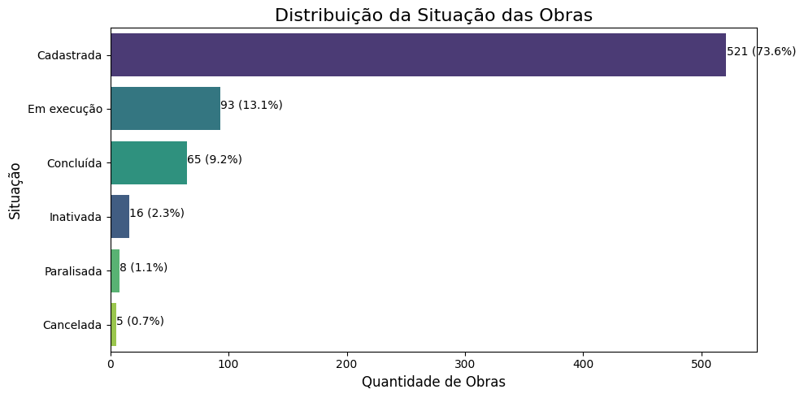

```python
df_obras = dfs_carregados['obras']

plt.figure(figsize=(10, 5))
ax_situacao = sns.countplot(data=df_obras, y='situacao', order=df_obras['situacao'].value_counts().index, palette='viridis', hue='situacao', legend=False)
plt.title('Distribuição da Situação das Obras', fontsize=16)
plt.xlabel('Quantidade de Obras', fontsize=12)
plt.ylabel('Situação', fontsize=12)
total_situacao = len(df_obras['situacao'])
for p in ax_situacao.patches:
    percentage = '{:.1f}%'.format(100 * p.get_width()/total_situacao)
    x = p.get_x() + p.get_width() + 0.02
    y = p.get_y() + p.get_height()/2
    ax_situacao.annotate(f"{int(p.get_width())} ({percentage})", (x, y))
plt.tight_layout()
plt.show()
```

**Conclusão**: O dataset é dominado por projetos em sua fase inicial de registro. Há uma carência significativa de dados sobre o ciclo de vida subsequente (execução, conclusão, paralisação). Isso implica que qualquer análise sobre o progresso real ou efetivo das obras será limitada a um subconjunto muito pequeno, enviesando as conclusões se não for tratado com cuidado.

### 5.2.2 Tipologia das Obras (Eixos e Tipos)

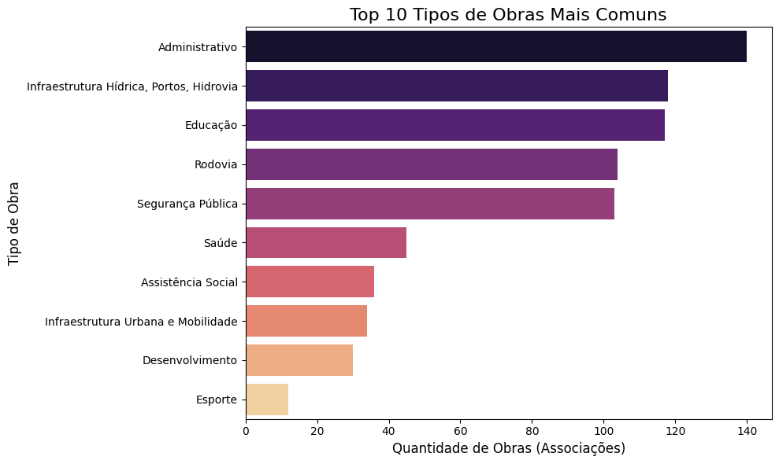

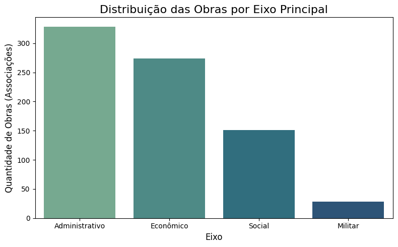

```python
# Criar Tabelas Lookup com os nomes únicos de Eixos e Tipos
df_eixos_lookup = dfs_carregados['obra_eixos'][['id', 'descricao']].drop_duplicates().reset_index(drop=True)
df_tipos_lookup = dfs_carregados['obra_tipos'][['id', 'descricao', 'idEixo']].drop_duplicates().reset_index(drop=True)

# Join Obras com seus Tipos (usando a subtabela de relacionamento 'df_obra_tipos')
df_obras_com_tipos_id = pd.merge(
    df_obras[['idUnico']],                 # Chave da tabela principal
    dfs_carregados['obra_tipos'][['idUnico', 'id']],      # Tabela de relacionamento
    on='idUnico',
    how='left'
)

# Join com as descrições dos Tipos (usando a df_tipos_lookup
df_obras_com_tipos_desc = pd.merge(
    df_obras_com_tipos_id,
    df_tipos_lookup[['id', 'descricao', 'idEixo']], # Tabela de lookup de tipos
    on='id',
    how='left'
)

# Join com as descrições dos Eixos (usando a df_eixos_lookup)
df_analise_tipologia = pd.merge(
    df_obras_com_tipos_desc,
    df_eixos_lookup.rename(columns={'id': 'idEixo', 'descricao': 'eixo_descricao'}), # Tabela de lookup de eixos
    on='idEixo',
    how='left'
)

# Plotar as contagens por descrição
top_tipos = df_analise_tipologia['descricao'].value_counts().nlargest(10)
plt.figure(figsize=(10, 6))
sns.barplot(x=top_tipos.values, y=top_tipos.index, palette='magma', hue=top_tipos.index, legend=False)
plt.title('Top 10 Tipos de Obras Mais Comuns', fontsize=16)
plt.xlabel('Quantidade de Obras (Associações)', fontsize=12)
plt.ylabel('Tipo de Obra', fontsize=12)
plt.tight_layout()
plt.show()

# Contagem para Eixos
eixos_counts = df_analise_tipologia['eixo_descricao'].value_counts()
plt.figure(figsize=(8, 5))
sns.barplot(x=eixos_counts.index, y=eixos_counts.values, palette='crest', hue=eixos_counts.index, legend=False)
plt.title('Distribuição das Obras por Eixo Principal', fontsize=16)
plt.xlabel('Eixo', fontsize=12)
plt.ylabel('Quantidade de Obras (Associações)', fontsize=12)
plt.tight_layout()
plt.show()
```

**Conclusão**: A análise hierárquica (Eixo -> Tipo) mostra que o foco principal dos projetos registrados nesta base de dados é administrativo. O resultado permite identificar que a categoria "Administrativo" domina tanto em nível macro (Eixo) quanto micro (Tipo).

### 5.2.3 Distribuição dos Valores de Investimento

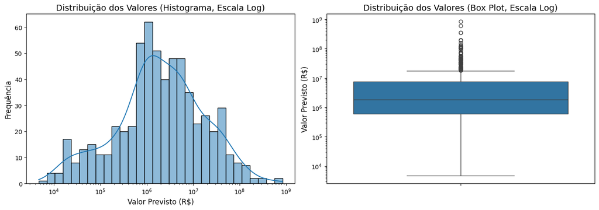

```
Estatísticas Descritivas do Valor de Investimento (por Fonte):
```

|  | valorInvestimentoPrevisto |
| --- | --- |
| count | 741.00 |
| mean | 11,329,303.63 |
| std | 46,518,388.72 |
| min | 0.00 |
| 25% | 76,800.00 |
| 50% | 1,180,000.00 |
| 75% | 5,577,265.40 |
| max | 839,664,954.32 |

```python
plt.figure(figsize=(14, 5))

# Histograma
plt.subplot(1, 2, 1)
# Filtrado > 1 para remover valores simbólicos (como 0.01000) porque eles prejudicam a escala
sns.histplot(dfs_carregados['obra_fontes_recurso'][dfs_carregados['obra_fontes_recurso']['valorInvestimentoPrevisto'] > 1]['valorInvestimentoPrevisto'], kde=True, bins=30, log_scale=True)
plt.title('Distribuição dos Valores (Histograma, Escala Log)', fontsize=14)
plt.xlabel('Valor Previsto (R$)', fontsize=12)
plt.ylabel('Frequência', fontsize=12)

# Box Plot
plt.subplot(1, 2, 2)
sns.boxplot(y=dfs_carregados['obra_fontes_recurso'][dfs_carregados['obra_fontes_recurso']['valorInvestimentoPrevisto'] > 1]['valorInvestimentoPrevisto'])
plt.title('Distribuição dos Valores (Box Plot, Escala Log)', fontsize=14)
plt.ylabel('Valor Previsto (R$)', fontsize=12)
plt.yscale('log')
plt.tight_layout()
plt.show()

print("Estatísticas Descritivas do Valor de Investimento (por Fonte):")
# Mostra média, mediana (50%), min, max, etc.
display(dfs_carregados['obra_fontes_recurso']['valorInvestimentoPrevisto'].describe().to_frame().style.format('{:,.2f}').set_table_styles(estilos_alinhamento))
```

**Conclusão**: O custo dos projetos é caracterizado por uma alta variabilidade e pela presença de outliers extremos de alto valor. Devido a essa assimetria, a mediana é uma métrica de tendência central se torna mais robusta e representativa do que a média (que seria inflada pelos outliers).

### 5.2.4 Distribuição da Duração Prevista

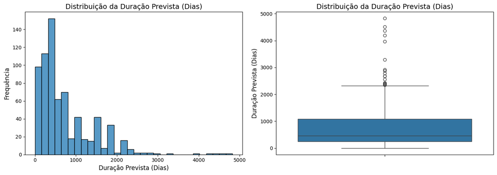

```
Estatísticas Descritivas da Duração Prevista (Dias):
```

|  | duracao_prevista_dias |
| --- | --- |
| count | 706 |
| mean | 723 |
| std | 686 |
| min | 0 |
| 25% | 248 |
| 50% | 456 |
| 75% | 1,079 |
| max | 4,827 |

```
### 5.2.5 Adoção da Metodologia BIM
```

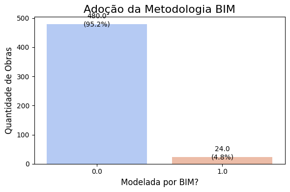

```python
df_obras['duracao_prevista_dias'] = (df_obras['dataFinalPrevista'] - df_obras['dataInicialPrevista']).dt.days
# Filtra durações negativas (inconsistentes) ou nulas
duracoes_validas = df_obras['duracao_prevista_dias'].dropna()
duracoes_validas = duracoes_validas[duracoes_validas >= 0]

plt.figure(figsize=(14, 5))
# Histograma
plt.subplot(1, 2, 1)
sns.histplot(duracoes_validas, kde=False, bins=30)
plt.title('Distribuição da Duração Prevista (Dias)', fontsize=14)
plt.xlabel('Duração Prevista (Dias)', fontsize=12)
plt.ylabel('Frequência', fontsize=12)

# Box Plot
plt.subplot(1, 2, 2)
sns.boxplot(y=duracoes_validas)
plt.title('Distribuição da Duração Prevista (Dias)', fontsize=14)
plt.ylabel('Duração Prevista (Dias)', fontsize=12)
plt.tight_layout()
plt.show()

print("Estatísticas Descritivas da Duração Prevista (Dias):")
display(duracoes_validas.describe().to_frame().style.format('{:,.0f}').set_table_styles(estilos_alinhamento))


# Coluna isModeladaPorBim da tabela principal
print("\n### 5.2.5 Adoção da Metodologia BIM")
plt.figure(figsize=(6, 4))
# Usamos dropna() para analisar apenas os registros que *tinham* essa informação
ax_bim = sns.countplot(data=df_obras.dropna(subset=['isModeladaPorBim']), x='isModeladaPorBim', palette='coolwarm', hue='isModeladaPorBim', legend=False)
plt.title('Adoção da Metodologia BIM', fontsize=16)
plt.xlabel('Modelada por BIM?', fontsize=12)
plt.ylabel('Quantidade de Obras', fontsize=12)
total_bim_info = len(df_obras['isModeladaPorBim'].dropna())
for p in ax_bim.patches:
    height = p.get_height()
    percentage = '{:.1f}%'.format(100 * height/total_bim_info) if total_bim_info > 0 else '0.0%'
    ax_bim.annotate(f'{height}\n({percentage})', (p.get_x() + p.get_width() / 2., height),
                ha='center', va='center', xytext=(0, 5), textcoords='offset points')
plt.tight_layout()
plt.show()
```

### 5.2.6 Entidades Executoras Mais Frequentes

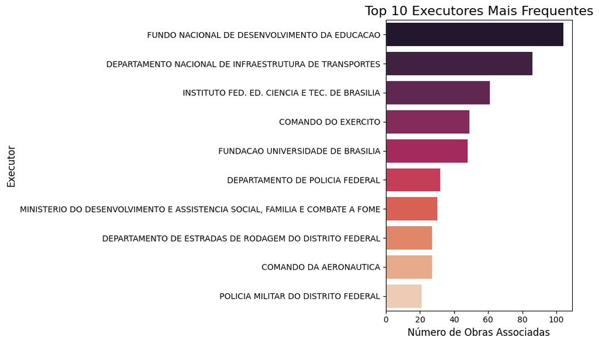

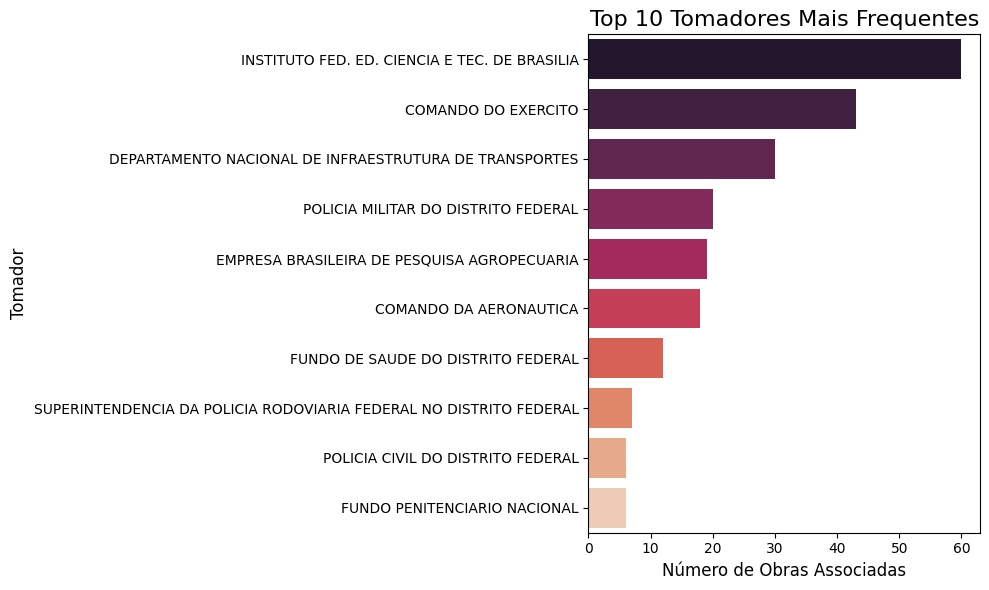

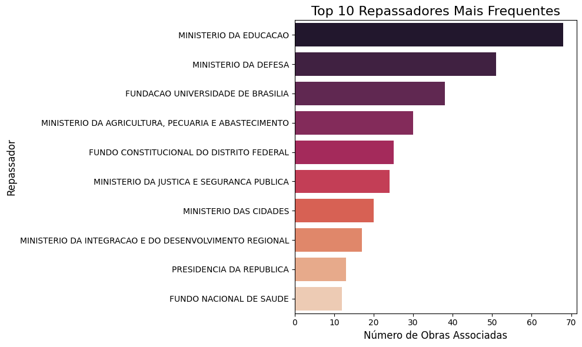

```python
try:
    query_exec = """
        SELECT nome, COUNT(idUnico) as contagem
        FROM obra_executores
        GROUP BY nome
        ORDER BY contagem DESC
        LIMIT 10;
    """
    df_top_exec = pd.read_sql_query(query_exec, engine)

    plt.figure(figsize=(10, 6))
    sns.barplot(data=df_top_exec, y='nome', x='contagem', palette='rocket', hue='nome', legend=False)
    plt.title('Top 10 Executores Mais Frequentes', fontsize=16)
    plt.xlabel('Número de Obras Associadas', fontsize=12)
    plt.ylabel('Executor', fontsize=12)
    plt.tight_layout()
    plt.show()

except Exception as e:
    print(f"Erro ao analisar executores via SQL: {e}")

try:
    query_exec = """
        SELECT nome, COUNT(idUnico) as contagem
        FROM obra_tomadores
        GROUP BY nome
        ORDER BY contagem DESC
        LIMIT 10;
    """
    df_top_exec = pd.read_sql_query(query_exec, engine)

    plt.figure(figsize=(10, 6))
    sns.barplot(data=df_top_exec, y='nome', x='contagem', palette='rocket', hue='nome', legend=False)
    plt.title('Top 10 Tomadores Mais Frequentes', fontsize=16)
    plt.xlabel('Número de Obras Associadas', fontsize=12)
    plt.ylabel('Tomador', fontsize=12)
    plt.tight_layout()
    plt.show()

except Exception as e:
    print(f"Erro ao analisar tomadores via SQL: {e}")

try:
    query_exec = """
        SELECT nome, COUNT(idUnico) as contagem
        FROM obra_repassadores
        GROUP BY nome
        ORDER BY contagem DESC
        LIMIT 10;
    """
    df_top_exec = pd.read_sql_query(query_exec, engine)

    plt.figure(figsize=(10, 6))
    sns.barplot(data=df_top_exec, y='nome', x='contagem', palette='rocket', hue='nome', legend=False)
    plt.title('Top 10 Repassadores Mais Frequentes', fontsize=16)
    plt.xlabel('Número de Obras Associadas', fontsize=12)
    plt.ylabel('Repassador', fontsize=12)
    plt.tight_layout()
    plt.show()

except Exception as e:
    print(f"Erro ao analisar repassadores via SQL: {e}")
```

**Conclusão**: As consultas às tabelas de relacionamento revelam que o ecossistema de execução não possui diversidade signficativa, na verdade, é dominado por poucas entidades-chave. Isso demonstra que uma entidade executa muitas obras (1->N)

## 5.3 Análise Bivariada / Multivariada

### 5.3.1 Estruturação Dataframes Relacionais

```python
# Agregar Valores de acordo com idUnico. Uma obra pode ter várias fontes de recurso.
df_invest_por_obra = dfs_carregados['obra_fontes_recurso'].groupby('idUnico')['valorInvestimentoPrevisto'].sum().reset_index()
print("Valores de investimento agregados por obra.")

# Criar o DataFrame Analítico Principal

df_analise = pd.merge(df_obras, df_invest_por_obra, on='idUnico', how='left')

# Utiliza a classificação de tipo/eixo (já calculada na seção univariada)
df_classificacao_primaria = df_analise_tipologia.drop_duplicates(subset='idUnico', keep='first')

# 4. Join o df_analise com as classificações primárias.
df_analise = pd.merge(df_analise,
                    df_classificacao_primaria[['idUnico', 'descricao', 'eixo_descricao']].rename(columns={'descricao': 'tipo_descricao'}),
                    on='idUnico',
                    how='left')

# Recalcular a Duração Prevista
df_analise['duracao_prevista_dias'] = (df_analise['dataFinalPrevista'] - df_analise['dataInicialPrevista']).dt.days
```

```
Valores de investimento agregados por obra.
```

### 5.3.2 Valor de Investimento por Eixo

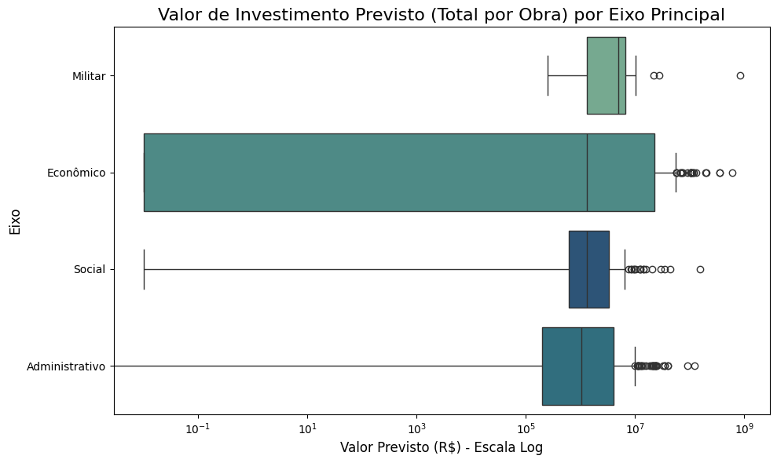

```python
# Filtra dados onde tem-se tanto valor quanto eixo
invest_eixo = df_analise.dropna(subset=['valorInvestimentoPrevisto', 'eixo_descricao'])
# Ordena os eixos usando  mediana de investimento
median_order_eixo = invest_eixo.groupby('eixo_descricao')['valorInvestimentoPrevisto'].median().sort_values(ascending=False).index

plt.figure(figsize=(10, 6))
sns.boxplot(data=invest_eixo, y='eixo_descricao', x='valorInvestimentoPrevisto', order=median_order_eixo, palette='crest', hue='eixo_descricao', legend=False)
plt.title('Valor de Investimento Previsto (Total por Obra) por Eixo Principal', fontsize=16)
plt.xlabel('Valor Previsto (R$) - Escala Log', fontsize=12)
plt.ylabel('Eixo', fontsize=12)
plt.xscale('log')
plt.tight_layout()
plt.show()
```

### 5.3.3 Duração Prevista por Eixo

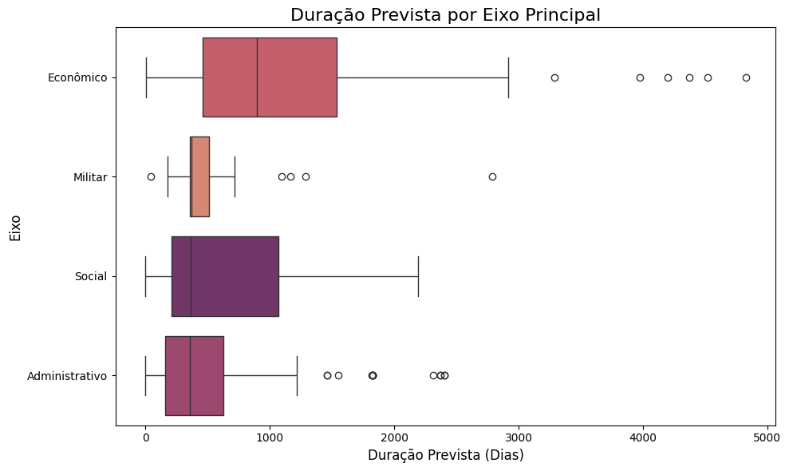

```python
# Filtra dados pela duração (so valores validos)
duracao_eixo = df_analise.dropna(subset=['duracao_prevista_dias', 'eixo_descricao'])
duracao_eixo = duracao_eixo[duracao_eixo['duracao_prevista_dias'] >= 0]
# Ordena pela mediana da duração
median_order_dur_eixo = duracao_eixo.groupby('eixo_descricao')['duracao_prevista_dias'].median().sort_values(ascending=False).index

plt.figure(figsize=(10, 6))
sns.boxplot(data=duracao_eixo, y='eixo_descricao', x='duracao_prevista_dias', order=median_order_dur_eixo, palette='flare', hue='eixo_descricao', legend=False)
plt.title('Duração Prevista por Eixo Principal', fontsize=16)
plt.xlabel('Duração Prevista (Dias)', fontsize=12)
plt.ylabel('Eixo', fontsize=12)
plt.tight_layout()
plt.show()
```

### 5.3.4 Relação Duração x Investimento

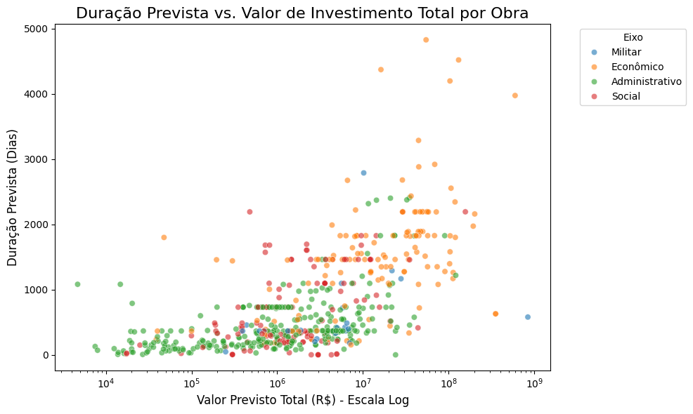

```python
# Filtra dados com valores válidos
duracao_invest = df_analise.dropna(subset=['duracao_prevista_dias', 'valorInvestimentoPrevisto'])
duracao_invest = duracao_invest[(duracao_invest['duracao_prevista_dias'] >= 0) & (duracao_invest['valorInvestimentoPrevisto'] > 1)] # Filtra valores inválidos ou placeholder

plt.figure(figsize=(10, 6))
sns.scatterplot(data=duracao_invest, x='valorInvestimentoPrevisto', y='duracao_prevista_dias', alpha=0.6, hue='eixo_descricao')
plt.title('Duração Prevista vs. Valor de Investimento Total por Obra', fontsize=16)
plt.xlabel('Valor Previsto Total (R$) - Escala Log', fontsize=12)
plt.ylabel('Duração Prevista (Dias)', fontsize=12)
plt.xscale('log')
plt.legend(title='Eixo', bbox_to_anchor=(1.05, 1), loc='upper left')
plt.tight_layout()
plt.show()
```

**Conclusão**: A relação entre custo e duração não é tao evidente, mostrando projetos que possuem duração prevista baixa, mas com alto valor. No entanto, o custo parece impor um "teto" para a duração; não encontramos projetos de longa duração e baixo custo (valores alto-esquerda). A análise reforça que projetos `Econômicos` dominam a região de altos custos e prazos.

### 5.3.5 Situação das Obras por Tipo

[figure not shown]

```python
# Top_tipos ja usada na analise univariada
top5_tipos_list = top_tipos.index.tolist()
# Filtra o df_analise para conter apenas os Top 5 tipos
df_situacao_tipo = df_analise[df_analise['tipo_descricao'].isin(top5_tipos_list)]

plt.figure(figsize=(12, 7))
sns.countplot(data=df_situacao_tipo, y='tipo_descricao', hue='situacao', order=top5_tipos_list, palette='Spectral')
plt.title('Situação das Obras por Tipo (Top 5 Tipos)', fontsize=16)
plt.xlabel('Quantidade de Obras', fontsize=12)
plt.ylabel('Tipo de Obra', fontsize=12)
plt.legend(title='Situação', bbox_to_anchor=(1.05, 1), loc='upper left')
plt.tight_layout()
plt.show()
```

**Conclusão**: Esta análise multivariada reforça o insight da análise univariada da situação: a base de dados é composta predominantemente por registros em fase inicial ("Cadastrada"). A análise por tipo não revela nenhuma exceção evidente a essa regra; por exemplo, não há um tipo de obra que esteja predominantemente "Em execução" ou "Concluída". Portanto a analise sobre o progresso ou desempenho comparativo entre diferentes tipos de projeto não gera resultados promissores e relevantes..

## 5.3 Anáise Temporal

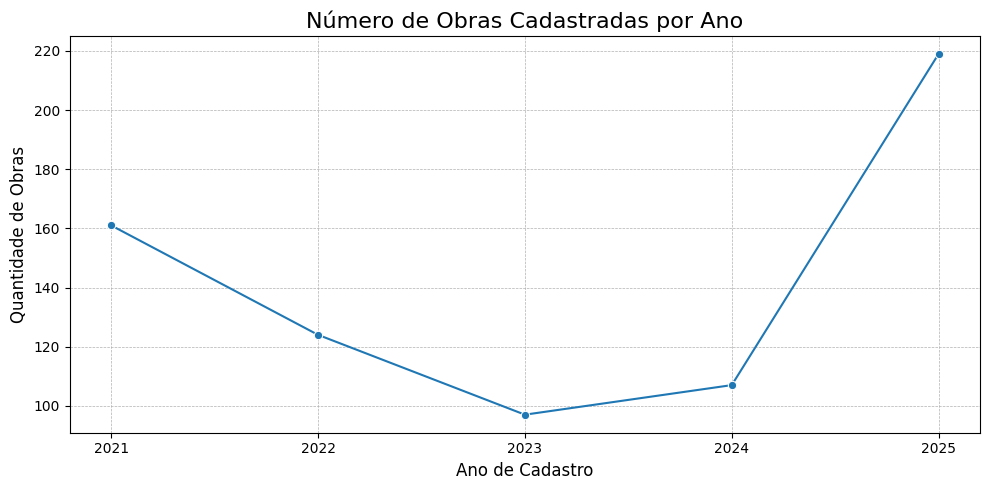

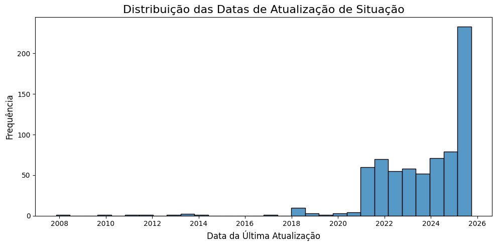

```python
# Cadastro de Obras por Ano
df_obras['ano_cadastro'] = df_obras['dataCadastro'].dt.year
cadastros_por_ano = df_obras['ano_cadastro'].value_counts().sort_index()

plt.figure(figsize=(10, 5))
sns.lineplot(x=cadastros_por_ano.index, y=cadastros_por_ano.values, marker='o')
plt.title('Número de Obras Cadastradas por Ano', fontsize=16)
plt.xlabel('Ano de Cadastro', fontsize=12)
plt.ylabel('Quantidade de Obras', fontsize=12)
plt.xticks(cadastros_por_ano.index.astype(int))
plt.grid(True, which='both', linestyle='--', linewidth=0.5)
plt.tight_layout()
plt.show()

# Atualização de Situação ao Longo do Tempo
plt.figure(figsize=(10, 5))
sns.histplot(df_obras['dataSituacao'].dropna(), bins=30, kde=False)
plt.title('Distribuição das Datas de Atualização de Situação', fontsize=16)
plt.xlabel('Data da Última Atualização', fontsize=12)
plt.ylabel('Frequência', fontsize=12)
plt.tight_layout()
plt.show()
```

# 6. Conclusão

## 6.1 Descobertas de Anomalias sobre a Qualidade da Fonte (API)

Após repetidas extrações dos dados, notou-se incoerência entre os metadados advindos da API. Exemplo desses erros são variaveis que dizem que a paginal final sempre é True, tornando a extração mais complicada. O numero ou quantiade de máxima de paginas também não são dados reais.

## 6.2 Conclusão da Análise de Qualidade

A análise microscópica revelou que os dados brutos extraídos da API ObrasGov.br possuem problemas críticos de qualidade, exigindo um processo substancial de limpeza e tratamento antes que qualquer análise confiável pudesse ser realizada.

1. Contaminação por Dados de Teste: A base continha múltiplos registros de teste (ex: "Ronald 1", "Obra de Desenvolvimento de Teste") e inconsistências lógicas (data final < data inicial) que precisaram ser identificados e removidos. Demonstrando falta de precisão dos dados em representar valores do contexto real.
2. Incompletude Crítica: A baixa qualidade de completude dos dados em diversas colunas prejudica demasiadamente análises quantitativas. Colunas cruciais como dataInicialEfetiva (96.5% nulos), dataFinalEfetiva (99.1% nulos), qdtEmpregosGerados (86% nulos) e populacaoBeneficiada (86% nulos) estão, na prática, inutilizáveis.
3. Problemas Estruturais e de Formato: Os dados não estavam em um formato analítico imediato. Sete colunas ("unhashable") continham listas de dicionários que exigiram normalização e a criação de um esquema relacional (tabelas separadas). Além disso, colunas de texto (como cep) apresentavam formatos inconsistentes e valores de placeholder (ex: '1', ' ').
4. Duplicatas de Chave: A coluna idUnico, que deveria ser um identificador, continha duplicatas, exigindo uma análise para entender que se tratava de atualizações sobre uma mesma obra.

## 6.3 Conclusões dos Insights Analíticos

Embora a qualidade dos dados estivessem precários, durante a análise qualitativa e quantitativa da base de dados, foi possível adiquirir alguns insights sobre o contexto e regras de negócio. Percebeu-se que o conjunto de dados não representa uma documentação estável das obras no DF, mas sim uma documentação massiva e recente de projetos, ja que a análise temporal mostrou um pico anômalo de cadastros em 2025. Essa descoberta principal explica os demais padrões observados:

A principal limitação da análise é a incapacidade de medir o progresso real ou o impacto socioeconômico das obras, devido à massiva ausência de dados nas colunas efetivas (ex: dataInicialEfetiva, qdtEmpregosGerados).